# S1 (Supplement Study 1)

Last update: 01/08/2023

# 1 Variable and scale preparation

## 1.1 Internal consistency: Affective risk

```r
# Name factors
data$T1_GENDER <- factor(data$T1_GENDER, levels = c(1,2), labels = c("male", "female"))
data$T1_EDUCATION <- factor(data$T1_EDUCATION, levels = c(1,2,3), labels = c("up to 9 years", "10+ years with UEQ", "10+ years without UEQ"))

# Scale preparation
data$VSTATUS <- ifelse(data$VACSTATUS == 5, 0, 1)

data$IDENT <- rowMeans(data[,c("IDENT_NOVAC_1", "IDENT_NOVAC_2", "IDENT_NOVAC_3", "IDENT_NOVAC_4", "IDENT_NOVAC_5", "IDENT_VAC_1", "IDENT_VAC_2", "IDENT_VAC_3", "IDENT_VAC_4", "IDENT_VAC_5")], na.rm = TRUE)

psych::alpha(data[c("AFF_THINK", "AFF_FEAR", "AFF_WORRY")])
```

```
##
## Reliability analysis
## Call: psych::alpha(x = data[c("AFF_THINK", "AFF_FEAR", "AFF_WORRY")])
##
##   raw_alpha std.alpha G6(smc) average_r S/N    ase mean  sd median_r
##       0.91      0.91    0.89      0.78  11 0.0037  4.7 1.7     0.76
##
##     95% confidence boundaries
##          lower alpha upper
## Feldt     0.91  0.91  0.92
## Duhachek  0.91  0.91  0.92
##
##  Reliability if an item is dropped:
##           raw_alpha std.alpha G6(smc) average_r  S/N alpha se var.r med.r
## AFF_THINK      0.93      0.93    0.86      0.86 12.5   0.0037    NA  0.86
## AFF_FEAR       0.83      0.84    0.72      0.72  5.1   0.0082    NA  0.72
## AFF_WORRY      0.86      0.86    0.76      0.76  6.2   0.0069    NA  0.76
##
##  Item statistics
##              n raw.r std.r r.cor r.drop mean  sd
## AFF_THINK 1644  0.89  0.89  0.79   0.76  5.0 1.7
## AFF_FEAR  1644  0.95  0.95  0.92   0.88  4.7 1.9
## AFF_WORRY 1644  0.94  0.93  0.89   0.85  4.4 1.9
##
## Non missing response frequency for each item
##              1    2    3    4    5    6    7 miss
## AFF_THINK 0.05 0.04 0.08 0.19 0.17 0.21 0.26    0
## AFF_FEAR  0.07 0.07 0.14 0.21 0.13 0.15 0.24    0
## AFF_WORRY 0.09 0.11 0.15 0.21 0.11 0.13 0.21    0
```

```r
data$AFFRISK <- 8-rowMeans(data[,c("AFF_THINK", "AFF_FEAR", "AFF_WORRY")], na.rm = TRUE)
```

```r
psych::alpha(data[c("T1_AFF_THINK", "T1_AFF_FEAR", "T1_AFF_WORRY")])
```

```
##
## Reliability analysis
## Call: psych::alpha(x = data[c("T1_AFF_THINK", "T1_AFF_FEAR", "T1_AFF_WORRY")])
##
##   raw_alpha std.alpha G6(smc) average_r S/N    ase mean  sd median_r
##       0.84      0.83    0.79      0.63 5.1 0.0069  3.7 1.5     0.58
##
##     95% confidence boundaries
##          lower alpha upper
## Feldt     0.82  0.84  0.85
## Duhachek  0.82  0.84  0.85
##
##  Reliability if an item is dropped:
##              raw_alpha std.alpha G6(smc) average_r S/N alpha se var.r med.r
## T1_AFF_THINK      0.86      0.86    0.76      0.76 6.2   0.0068    NA  0.76
## T1_AFF_FEAR       0.70      0.71    0.55      0.55 2.4   0.0144    NA  0.55
## T1_AFF_WORRY      0.73      0.73    0.58      0.58 2.7   0.0133    NA  0.58
##
##  Item statistics
##                 n raw.r std.r r.cor r.drop mean  sd
## T1_AFF_THINK 1644   0.8  0.82  0.64   0.60  4.1 1.6
## T1_AFF_FEAR  1644   0.9  0.90  0.84   0.77  3.8 1.8
## T1_AFF_WORRY 1644   0.9  0.89  0.82   0.74  3.4 1.9
##
## Non missing response frequency for each item
##                 1    2    3    4    5    6    7 miss
## T1_AFF_THINK 0.05 0.12 0.18 0.28 0.19 0.11 0.08    0
## T1_AFF_FEAR  0.11 0.14 0.21 0.22 0.11 0.10 0.11    0
## T1_AFF_WORRY 0.19 0.20 0.19 0.17 0.10 0.07 0.09    0
```

```r
data$T1_AFFRISK <- 8-rowMeans(data[,c("T1_AFF_THINK", "T1_AFF_FEAR", "T1_AFF_WORRY")], na.rm = TRUE)

#psych::alpha(data[c("AFF_THINK_SUMMER", "AFF_FEAR_SUMMER", "AFF_WORRY_SUMMER")])
data$AFFRISK_SUMMER <- 8-rowMeans(data[,c("AFF_THINK_SUMMER", "AFF_FEAR_SUMMER", "AFF_WORRY_SUMMER")], na.rm = TRUE)

#psych::alpha(data[c("AFF_THINK_WINTER", "AFF_FEAR_WINTER", "AFF_WORRY_WINTER")])
data$AFFRISK_WINTER <- 8-rowMeans(data[,c("AFF_THINK_WINTER", "AFF_FEAR_WINTER", "AFF_WORRY_WINTER")], na.rm = TRUE)
```

## 1.2 Internal consistency: Appropriateness of political action

```r
data$EXPERIENCE_SEVERECASES_R <- ifelse(data$EXPERIENCE_SEVERECASES == 2, 0, 1)
data$EXPERIENCE_DEATHS_R <- ifelse(data$EXPERIENCE_DEATHS == 2, 0, 1)
data$FINLOSS_R <- ifelse(data$FINLOSS == 2, 0, 1)

data$CRT_BALL_CORRECT <- ifelse(data$CRT_BALL == 5, 1, 0)
data$CRT_MACHINES_CORRECT <- ifelse(data$CRT_MACHINES == 5, 1, 0)
data$CRT <- data$CRT_BALL_CORRECT + data$CRT_MACHINES_CORRECT

data$RECAP_1_R <- 8 - data$RECAP_1
data$RECAP_2_R <- 8 - data$RECAP_2
data$RECAP_4_R <- 8 - data$RECAP_4

psych::alpha(data[,c("RECAP_1_R", "RECAP_2_R", "RECAP_3", "RECAP_4_R", "RECAP_5", "RECAP_6", "RECAP_7", "RECAP_8", "RECAP_9")], check.keys = TRUE)
```

```
##
## Reliability analysis
## Call: psych::alpha(x = data[, c("RECAP_1_R", "RECAP_2_R", "RECAP_3",
##     "RECAP_4_R", "RECAP_5", "RECAP_6", "RECAP_7", "RECAP_8",
##     "RECAP_9")], check.keys = TRUE)
##
##   raw_alpha std.alpha G6(smc) average_r S/N    ase mean  sd median_r
##       0.92      0.92    0.92      0.55  11 0.0029  3.8 1.6     0.56
##
##     95% confidence boundaries
##          lower alpha upper
## Feldt     0.91  0.92  0.92
## Duhachek  0.91  0.92  0.92
##
##  Reliability if an item is dropped:
##           raw_alpha std.alpha G6(smc) average_r  S/N alpha se var.r med.r
## RECAP_1_R      0.93      0.92    0.93      0.61 12.3   0.0026 0.023  0.63
## RECAP_2_R      0.91      0.90    0.91      0.54  9.3   0.0033 0.036  0.50
## RECAP_3        0.90      0.90    0.91      0.53  9.1   0.0035 0.033  0.51
## RECAP_4_R      0.92      0.91    0.92      0.57 10.4   0.0030 0.034  0.63
## RECAP_5        0.90      0.90    0.90      0.52  8.8   0.0036 0.028  0.50
## RECAP_6        0.90      0.90    0.90      0.52  8.8   0.0036 0.028  0.50
## RECAP_7        0.91      0.90    0.91      0.54  9.3   0.0034 0.032  0.51
## RECAP_8        0.92      0.92    0.93      0.60 12.0   0.0028 0.024  0.63
## RECAP_9        0.90      0.90    0.91      0.53  8.9   0.0035 0.031  0.50
##
##  Item statistics
##              n raw.r std.r r.cor r.drop mean  sd
## RECAP_1_R 1644  0.55  0.55  0.46   0.44  4.0 2.0
## RECAP_2_R 1644  0.82  0.82  0.80   0.77  3.9 2.1
## RECAP_3   1644  0.85  0.85  0.84   0.80  4.2 2.1
## RECAP_4_R 1644  0.72  0.71  0.66   0.63  3.6 2.1
## RECAP_5   1644  0.88  0.88  0.89   0.84  3.2 2.2
## RECAP_6   1644  0.88  0.88  0.88   0.84  3.1 2.3
## RECAP_7   1644  0.83  0.83  0.81   0.78  4.2 2.3
## RECAP_8   1644  0.56  0.57  0.49   0.47  4.4 1.8
## RECAP_9   1644  0.87  0.87  0.87   0.83  3.9 2.1
##
## Non missing response frequency for each item
##              1    2    3    4    5    6    7 miss
## RECAP_1_R 0.14 0.15 0.16 0.20 0.10 0.09 0.18    0
## RECAP_2_R 0.14 0.17 0.16 0.16 0.09 0.09 0.19    0
## RECAP_3   0.16 0.12 0.10 0.17 0.13 0.09 0.22    0
## RECAP_4_R 0.22 0.17 0.12 0.17 0.08 0.08 0.17    0
## RECAP_5   0.37 0.12 0.08 0.13 0.08 0.06 0.16    0
## RECAP_6   0.42 0.10 0.06 0.12 0.08 0.06 0.14    0
## RECAP_7   0.19 0.13 0.07 0.15 0.10 0.09 0.26    0
## RECAP_8   0.08 0.09 0.11 0.24 0.16 0.14 0.18    0
## RECAP_9   0.17 0.15 0.10 0.18 0.11 0.09 0.19    0
```

```r
data$RECAP <- 8-rowMeans(data[,c("RECAP_1_R", "RECAP_2_R", "RECAP_3", "RECAP_4_R", "RECAP_5", "RECAP_6", "RECAP_7", "RECAP_8", "RECAP_9")], na.rm=TRUE)
```

# 2 Descriptives

## 2.1 Demographics

### 2.1.1 Age

```r
psych::describe(data$T1_AGE)
```

```
##    vars    n  mean    sd median trimmed   mad min max range  skew kurtosis   se
## X1    1 1644 52.68 12.75     55   53.49 13.34  18  74    56 -0.52    -0.51 0.31
```

### 2.1.2 Gender

```r
prop.table(table(data$T1_GENDER))
```

```
##
##      male    female
## 0.4920925 0.5079075
```

### 2.1.3 Comparison by vaccination status

Age, gender and vaccination status identification by vaccination status:

```r
data$VSTATUS_NAMED <- factor(data$VSTATUS, levels = c(0, 1), labels = c("Unvaccinated", "Vaccinated"))
comparisons <-compareGroups::compareGroups(VSTATUS_NAMED ~ T1_AGE + T1_GENDER + IDENT, data = data)
compareGroups::createTable(comparisons, show.all=TRUE)
```

```
##
## --------Summary descriptives table by 'VSTATUS_NAMED'---------
##
## _________________________________________________________
##               [ALL]    Unvaccinated Vaccinated  p.overall
##              N=1644       N=426       N=1218
## ¯¯¯¯¯¯¯¯¯¯¯¯¯¯¯¯¯¯¯¯¯¯¯¯¯¯¯¯¯¯¯¯¯¯¯¯¯¯¯¯¯¯¯¯¯¯¯¯¯¯¯¯¯¯¯¯¯
## T1_AGE     52.7 (12.8) 50.5 (12.8)  53.5 (12.6)  <0.001
## T1_GENDER:                                        0.139
##     male   809 (49.2%) 196 (46.0%)  613 (50.3%)
##     female 835 (50.8%) 230 (54.0%)  605 (49.7%)
## IDENT      4.54 (1.33) 4.66 (1.29)  4.50 (1.34)   0.033
## ¯¯¯¯¯¯¯¯¯¯¯¯¯¯¯¯¯¯¯¯¯¯¯¯¯¯¯¯¯¯¯¯¯¯¯¯¯¯¯¯¯¯¯¯¯¯¯¯¯¯¯¯¯¯¯¯¯
```

# 3 Recall (population model)

```r
# Preparation

data$RE_PROB <- ifelse(data$T1 == "summer", data$PROB_SUMMER, data$PROB_WINTER)
data$BIAS_PROB <- data$RE_PROB - data$T1_PROB
data$BIAS_STD_PROB <- data$BIAS_PROB/sd(data$BIAS_PROB, na.rm = TRUE)

data$RE_SEVERITY <- ifelse(data$T1 == "summer", data$SEVERITY_SUMMER, data$SEVERITY_WINTER)
data$BIAS_SEVERITY <- data$RE_SEVERITY - data$T1_SEVERITY
data$BIAS_STD_SEVERITY <- data$BIAS_SEVERITY/sd(data$BIAS_SEVERITY, na.rm = TRUE)

data$RE_AFFRISK <- ifelse(data$T1 == "summer", data$AFFRISK_SUMMER, data$AFFRISK_WINTER)
data$BIAS_AFFRISK <- data$RE_AFFRISK - data$T1_AFFRISK
data$BIAS_STD_AFFRISK <- data$BIAS_AFFRISK/sd(data$BIAS_AFFRISK, na.rm = TRUE)

data$RE_TRUST_GOV <- ifelse(data$T1 == "summer", data$TRUST_GOV_SUMMER, data$TRUST_GOV_WINTER)
data$BIAS_TRUST_GOV <- data$RE_TRUST_GOV - data$T1_TRUST_GOV
data$BIAS_STD_TRUST_GOV <- data$BIAS_TRUST_GOV/sd(data$BIAS_TRUST_GOV, na.rm = TRUE)

data$RE_TRUST_SCIENCE <- ifelse(data$T1 == "summer", data$TRUST_SCIENCE_SUMMER, data$TRUST_SCIENCE_WINTER)
data$BIAS_TRUST_SCIENCE <- data$RE_TRUST_SCIENCE - data$T1_TRUST_SCIENCE
data$BIAS_STD_TRUST_SCIENCE <- data$BIAS_TRUST_SCIENCE/sd(data$BIAS_TRUST_SCIENCE, na.rm = TRUE)

data$RE_TRUST_RKI <- ifelse(data$T1 == "summer", data$TRUST_RKI_SUMMER, data$TRUST_RKI_WINTER)
data$BIAS_TRUST_RKI <- data$RE_TRUST_RKI - data$T1_TRUST_RKI
data$BIAS_STD_TRUST_RKI <- data$BIAS_TRUST_RKI/sd(data$BIAS_TRUST_RKI, na.rm = TRUE)

data$RE_USE_MASK <- ifelse(data$T1 == "summer", data$USE_MASK_SUMMER, data$USE_MASK_WINTER)
data$BIAS_USE_MASK <- data$RE_USE_MASK - data$T1_USE_MASK
data$BIAS_STD_USE_MASK <- data$BIAS_USE_MASK/sd(data$BIAS_USE_MASK, na.rm = TRUE)

data$RE_EXAGG <- ifelse(data$T1 == "summer", data$EXAGG_SUMMER, data$EXAGG_WINTER)
data$BIAS_EXAGG <- data$RE_EXAGG - data$T1_EXAGG
data$BIAS_STD_EXAGG <- data$BIAS_EXAGG/sd(data$BIAS_EXAGG, na.rm = TRUE)

data$RE_LIFESAT <- ifelse(data$T1 == "summer", data$LIFESAT_SUMMER, data$LIFESAT_WINTER)
data$BIAS_LIFESAT <- data$RE_LIFESAT - data$T1_LIFESAT
data$BIAS_STD_LIFESAT <- data$BIAS_LIFESAT/sd(data$BIAS_LIFESAT, na.rm = TRUE)

variables <- c("PROB", "SEVERITY", "AFFRISK", "TRUST_GOV", "TRUST_SCIENCE", "TRUST_RKI", "USE_MASK", "EXAGG", "LIFESAT")
variables.names <- c(
    "PROB" = "Infection probability",
    "SEVERITY" = "Infection severity",
    "AFFRISK" = "Affective risk",
    "TRUST_GOV" = "Trust in government",
    "TRUST_SCIENCE" = "Trust in science",
    "TRUST_RKI" = "Trust in RKI",
    "USE_MASK" = "Mask wearing",
    "EXAGG" = "Exaggeration perception",
    "LIFESAT" = "Life satisfaction"
)

t1variables <- paste0("T1_", variables)
t1variables.names <- variables.names
names(t1variables.names) <- paste0("T1_", names(t1variables.names))

revariables <- paste0("RE_", variables)
revariables.names <- variables.names
names(revariables.names) <- paste0("RE_", names(revariables.names))

biasvariables <- paste0("BIAS_", variables)
biasvariables.names <- variables.names
names(biasvariables.names) <- paste0("BIAS_", names(biasvariables.names))

stdbiasvariables <- paste0("BIAS_STD_", variables)
stdbiasvariables.names <- variables.names
names(stdbiasvariables.names) <- paste0("BIAS_STD_", names(stdbiasvariables.names))
```

## 3.1 Visualization

### 3.1.1 Distributions

```r
variables_bias_figure <- c("BIAS_PROB", "BIAS_SEVERITY", "BIAS_AFFRISK", "BIAS_TRUST_GOV", "BIAS_TRUST_SCIENCE", "BIAS_USE_MASK", "BIAS_EXAGG", "BIAS_LIFESAT")

variables_bias_figure.names <- c(
  "BIAS_PROB" = "Infection probability",
  "BIAS_SEVERITY" = "Infection severity",
  "BIAS_AFFRISK" = "Affective risk",
  "BIAS_TRUST_GOV" = "Trust in government",
  "BIAS_TRUST_SCIENCE" = "Trust in science",
  "BIAS_USE_MASK" = "Mask wearing",
  "BIAS_EXAGG" = "Exaggeration perception",
  "BIAS_LIFESAT" = "Life satisfaction"
)

data_high_VSI <- subset(data,data$IDENT >= 4)
data_low_VSI <- subset(data,data$IDENT < 4)

hist_fun <- function(dataset,variable, title_label){
  data_plot <- dataset[c(variable,"VSTATUS")]
  data_plot$VSTATUS <- ifelse(data_plot$VSTATUS == 1, "Vaccinated","Unvaccinated")
  data_plot$VSTATUS <- factor(data_plot$VSTATUS)

  colnames(data_plot) <- c("x_var","VSTATUS")
  ggplot(data = data_plot, aes(x = x_var , y = (after_stat(count)) / sum(after_stat(count)),  fill = VSTATUS)) +
  geom_histogram(binwidth = 1, position = "dodge") +  # Use 'position = "dodge"' for side-by-side histograms
    labs(title = title_label,
         x = "Recall of past  - Actual past rating",
         y = "Frequency") +
  scale_fill_manual(values = c("#FF7000","#8D9EFF"),guide = guide_legend(title = NULL))+
  geom_vline(xintercept = mean(data_plot$x_var[data_plot$VSTATUS == "Vaccinated"], na.rm=TRUE), linetype = "solid", color = "#8D9EFF") +
  geom_vline(xintercept = mean(data_plot$x_var[data_plot$VSTATUS == "Unvaccinated"], na.rm=TRUE), linetype = "solid", color = "#FF7000")+
  scale_x_continuous(limits = c(-7.2,7.2),breaks = seq(-7,7,1)) +
  scale_y_continuous(limits = c(0, 0.45)) +
    theme_bw()+
    theme( panel.grid.major = element_blank(),
           panel.grid.minor = element_blank(),
           plot.title = element_text(hjust = 0.5))

}

plot_list_high <- list()
plot_list_low <- list()

# Loop through the variables and generate plots
for (variable in variables_bias_figure) {
  plot_list_high[[variable]] <- hist_fun(data_high_VSI,variable,variables_bias_figure.names[variable])
}

for (variable in variables_bias_figure) {
  plot_list_low[[variable]] <- hist_fun(data_low_VSI,variable,variables_bias_figure.names[variable])
}
```

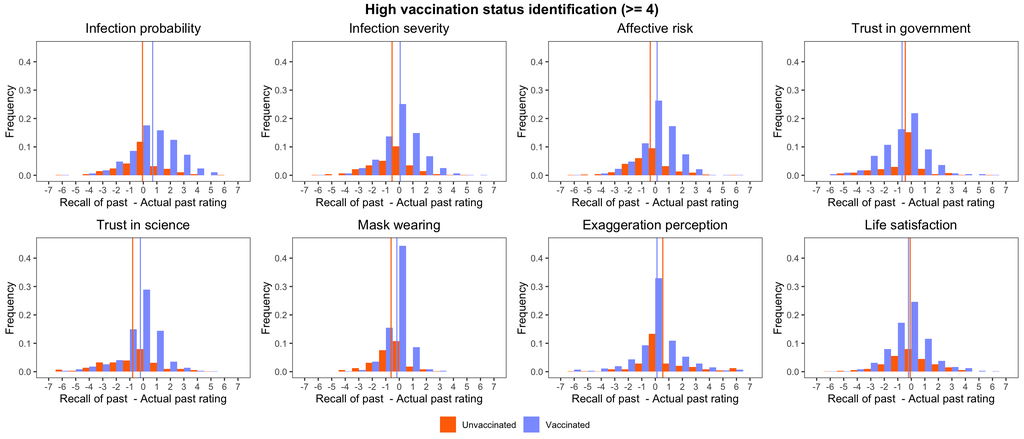

```r
combined_plot_high <- ggarrange(plotlist = plot_list_high, ncol = 4, nrow = 2, common.legend = TRUE,legend = "bottom")

combined_plot_high <- annotate_figure(combined_plot_high, top = text_grob("High vaccination status identification (>= 4)",
                                      face = "bold", size = 14))
ggsave("combined_plots_high_VSI.pdf", combined_plot_high, width = 14, height = 6)
combined_plot_high
```

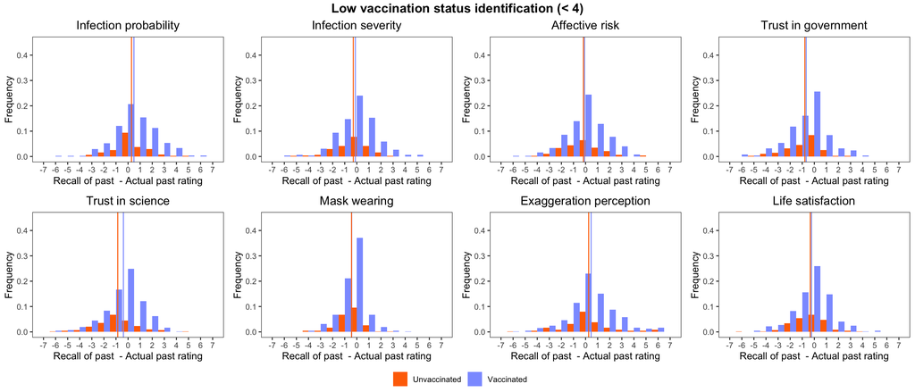

```r
combined_plot_low <- ggarrange(plotlist = plot_list_low, ncol = 4, nrow = 2, common.legend = TRUE,legend = "bottom")

combined_plot_low <- annotate_figure(combined_plot_low, top = text_grob("Low vaccination status identification (< 4)",
                                                                          face = "bold", size = 14))

ggsave("combined_plots_low_VSI.pdf", combined_plot_low, width = 14, height = 6)

combined_plot_low
```

### 3.1.2 T&B Model

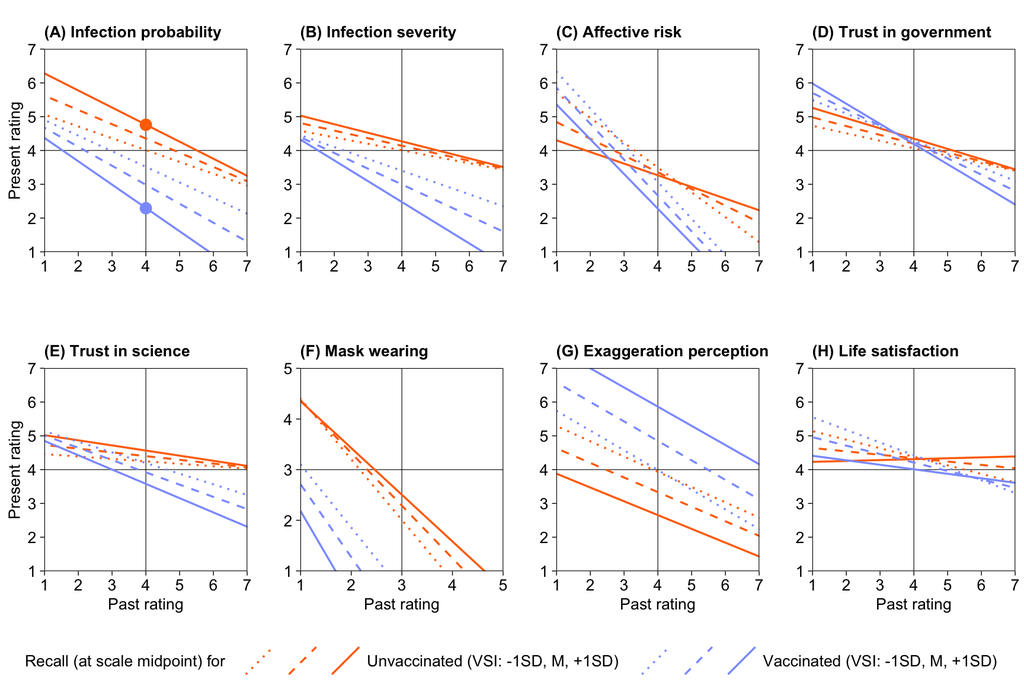

```r
getLineParams <- function(p1, p2) {
  m = (p1[2]-p2[2])/(p1[1]-p2[1])
  n = p1[2] - m * p1[1]
  return(c(m,n))
}

plotcounter = 0
chars = c("A", "B", "C", "D", "E", "F", "G", "H")

plotTBM <- function(variable) {

  plotcounter <<- plotcounter + 1;

  explainer_vac = data.frame(TRUTH = numeric(), BIAS = numeric(), RECALL = numeric())
  if (plotcounter == 1) {
    explainer_vac <- data.frame(TRUTH = 4, BIAS = 2.29, RECALL = 0)
  }

  explainer_novac = data.frame(TRUTH = numeric(), BIAS = numeric(), RECALL = numeric())
  if (plotcounter == 1) {
    explainer_novac <- data.frame(TRUTH = 4, BIAS = 4.76, RECALL = 0)
  }

  truthVar <- paste0("T1_", variable)
  biasVar <- variable
  recallVar <- paste0("RE_", variable)
  min <- 1
  max <- max(data[variable])
  mid <- min + (max-min)/2

  mean <- mean(data$IDENT)
  plusSD <- mean(data$IDENT)+sd(data$IDENT)
  minusSD <- mean(data$IDENT)-sd(data$IDENT)

  plotdata <- as.data.frame(expand.grid(c(((min*100):(max*100)))/100, c((min*100):(max*100))/100, c(0,1), c(plusSD, mean, minusSD)))
  names(plotdata) <- c(truthVar, biasVar, "VSTATUS", "IDENT")
  plotdata$RECALL <- pmax(pmin(predict(lm(formula=paste(recallVar, "~", truthVar, "*VSTATUS*IDENT +", biasVar, "*VSTATUS*IDENT"), data = data), plotdata), max), min)
  names(plotdata) <- c("TRUTH", "BIAS", "VSTATUS", "IDENT", "RECALL")

  lines <- data.frame(
    VSTATUS = character(),
    IDENT = character(),
    M = numeric(),
    N = numeric(),
    stringsAsFactors = FALSE
  )

  for (v in c(0,1)) {
    for (i in c(minusSD, mean, plusSD)) {

    subset <- plotdata[plotdata$VSTATUS == v & plotdata$IDENT == i,]

    p1_left <- as.numeric(subset %>% filter(TRUTH == min) %>% filter(abs(RECALL-mid)==min(abs(RECALL-mid))) %>% select(TRUTH, BIAS, RECALL))
    p1_top <- as.numeric(subset %>% filter(BIAS == max) %>% filter(abs(RECALL-mid)==min(abs(RECALL-mid))) %>% select(TRUTH, BIAS, RECALL))
    if(abs(p1_left[3]-mid) < abs(p1_top[3]-mid)) {
      p1 <- p1_left
    } else {
      p1 <- p1_top
    }

    p2_right <- as.numeric(subset %>% filter(TRUTH == max) %>% filter(abs(RECALL-mid)==min(abs(RECALL-mid))) %>% select(TRUTH, BIAS, RECALL))
    p2_bottom <- as.numeric(subset %>% filter(BIAS == min) %>% filter(abs(RECALL-mid)==min(abs(RECALL-mid))) %>% select(TRUTH, BIAS, RECALL))
    if(abs(p2_right[3]-mid) < abs(p2_bottom[3]-mid)) {
      p2 <- p2_right
    } else {
      p2 <- p2_bottom
    }

    lines[nrow(lines)+1,] <- list(v, i, getLineParams(p1, p2)[1], getLineParams(p1, p2)[2])

    }}

  lines$IDENT_NAME <- ifelse(lines$IDENT == mean, "M", ifelse(lines$IDENT == minusSD, "-1SD", "+1SD"))
  lines$IDENT_X_VSTATUS <- paste0(lines$VSTATUS, lines$IDENT_NAME)

  lines$IDENT_X_VSTATUS <- factor(lines$IDENT_X_VSTATUS, levels = c("0-1SD", "0M", "0+1SD", "1-1SD", "1M", "1+1SD"))



  ggplot(data=plotdata, aes(TRUTH, BIAS, z = RECALL)) +
    geom_raster(fill = "#ffffff") +
    theme_minimal(
    #) + facet_grid(
    #  . ~ VSTATUS,
    #  labeller = labeller(VSTATUS = c("0" = "Unvaccinated", "1" = "Vaccinated"))
    #) + scale_fill_gradientn(
    #  name = "Recall",
    #  breaks = c(min,max),
    #  limits = c(min,max),
    #  labels = c("1", "5 or 7"),
    #  colours = c("#8D9EFF", "#FFFFFF", "#FF7000")
    ) + scale_x_continuous(
      name = ifelse(plotcounter %in% c(5,6,7,8), "Past rating", ""),
      breaks = c(min:max)
    ) + scale_y_continuous(
      name = ifelse(plotcounter %in% c(1,5), "Present rating", ""),
      breaks = c(min:max)
    ) + theme(
      panel.grid = element_blank(),
      panel.border = element_rect(colour = "#000000", linetype="solid", fill=NA, size=0.4),
      axis.ticks.x = element_line(color = "#000000", linetype = "solid", size=0.25),
      axis.ticks.y = element_line(color = "#000000", linetype = "solid", size=0.25),
      strip.text = element_text(color="#000000", size=10, angle=0),
      axis.text.y = element_text(color="#000000", size=10, angle=0),
      axis.title.y = element_text(color="#000000", size=10, angle=90),
      axis.title.x = element_text(color="#000000", size=10, angle=0),
      axis.text.x = element_text(color="#000000", size=10, angle=0),
      plot.title = element_text(color="#000000", size=10, angle=0, face="bold"),
      legend.text = element_text(color="#000000", size=10, angle=0),
      legend.title = element_text(color="#000000", size=10, angle=0),
      legend.position = "bottom"
    ) + coord_fixed(
      ratio=1,
      expand = 0
    ) + geom_hline(
      yintercept = mid,
      size = 0.2
    ) + geom_vline(
      xintercept = mid,
      size = 0.2
    ) + geom_abline(
      data=lines,
      aes(slope=M, intercept=N, linetype=IDENT_X_VSTATUS, color=IDENT_X_VSTATUS),
      size=0.6
    ) + scale_linetype_manual(
      name = "Recall (at scale midpoint) for   ",
      labels = c(
        "0-1SD" = "",
        "0M" = "",
        "0+1SD" = "Unvaccinated (VSI: -1SD, M, +1SD)   ",
        "1-1SD" = "",
        "1M" = "",
        "1+1SD" = "Vaccinated (VSI: -1SD, M, +1SD)"
      ),
      values = c(
        "0-1SD" = "dotted",
        "0M" = "dashed",
        "0+1SD" = "solid",
        "1-1SD" = "dotted",
        "1M" = "dashed",
        "1+1SD" = "solid"
      )
    ) + scale_color_manual(
      name = "Recall (at scale midpoint) for   ",
      labels = c(
        "0-1SD" = "",
        "0M" = "",
        "0+1SD" = "Unvaccinated (VSI: -1SD, M, +1SD)   ",
        "1-1SD" = "",
        "1M" = "",
        "1+1SD" = "Vaccinated (VSI: -1SD, M, +1SD)"
      ),
      values = c(
        "0-1SD" = "#FF7000",
        "0M" = "#FF7000",
        "0+1SD" = "#FF7000",
        "1-1SD" = "#8D9EFF",
        "1M" = "#8D9EFF",
        "1+1SD" = "#8D9EFF"
      )
    ) + ggtitle(
      paste0("(", chars[plotcounter], ") ", variables.names[variable])
    ) +guides(linetype=guide_legend(nrow=1,byrow=TRUE)) + geom_point(data = explainer_vac, col = '#8D9EFF', size=3) + geom_point(data = explainer_novac, col = '#FF7000', size=3)

}

plotlist <- purrr::map(variables[variables!="TRUST_RKI"], plotTBM)
#plotlist <- c(list(plot_example), plotlist)
fig_1 <- ggarrange(plotlist=plotlist, common.legend = TRUE, legend = "bottom", align = "hv", ncol=4, nrow=2)

fig_1
```

```r
#png("fig_1.png",height=13,width=22,units="cm",res=300)
#print(fig_1)
#dev.off()

#pdf("fig_1.pdf",height=6,width=10)
#print(fig_1)
#dev.off()
```

## 3.2 Regression tables

Each analyses is performed for all participants and separately for participants from summer and winter periods.

### 3.2.1 Infection probability

```r
# center all variables by the grand mean of the truth (current rating)
data$RE_PROB_C <- datawizard::center(data$RE_PROB, reference=data$T1_PROB)
data$T1_PROB_C <- datawizard::center(data$T1_PROB, reference=data$T1_PROB)
data$PROB_C <- datawizard::center(data$PROB, reference=data$T1_PROB)

model <- lm(RE_PROB_C ~ factor(VSTATUS) * IDENT * T1_PROB_C + factor(VSTATUS) * IDENT * PROB_C, data = data)
model_summer <- lm(RE_PROB_C ~ factor(VSTATUS) * IDENT * T1_PROB_C + factor(VSTATUS) * IDENT * PROB_C, data = data[data$T1 == "summer",])
model_winter <- lm(RE_PROB_C ~ factor(VSTATUS) * IDENT * T1_PROB_C + factor(VSTATUS) * IDENT * PROB_C, data = data[data$T1 == "winter",])
tab_model(model, model_summer, model_winter, pred.labels = c(
  "T1_PROB_C" = "Past evaluation",
  "PROB_C" = "Present evaluation",
  "factor(VSTATUS)1" = "Vaccinated (Baseline: unvaccinated)",
  "IDENT" = "Vaccination status identification",
  "factor(VSTATUS)1:T1_PROB_C" = "Interaction: Past evaluation x Vaccinated",
  "IDENT:T1_PROB_C" = "Interaction: Past evaluation x Identification",
  "factor(VSTATUS)1:IDENT" = "Interaction: Vaccinated x Identification",
  "factor(VSTATUS)1:PROB_C" = "Interaction: Present evaluation x Vaccinated",
  "IDENT:PROB_C" = "Interaction: Present evaluation x Identification",
  "factor(VSTATUS)1:IDENT:T1_PROB_C" = "Interaction: Past evaluation x Vaccinated x Identification",
  "factor(VSTATUS)1:IDENT:PROB_C" = "Interaction: Present evaluation x Vaccinated x Identification"
), dv.labels = c("All", "Summer 2020", "Winter 2020/2021"), title = "Recall of infection probability", show.std=TRUE)
```

Recall of infection probability

|  | All |  |  |  |  |  | Summer 2020 |  |  |  |  |  | Winter 2020/2021 |  |  |  |  |  |
| --- | --- | --- | --- | --- | --- | --- | --- | --- | --- | --- | --- | --- | --- | --- | --- | --- | --- | --- |
| Predictors | Estimates | std. Beta | CI | standardized CI | p | std. p | Estimates | std. Beta | CI | standardized CI | p | std. p | Estimates | std. Beta | CI | standardized CI | p | std. p |
| (Intercept) | 0.53 | -0.27 | -0.04 – 1.10 | -0.35 – -0.18 | 0.066 | **<0.001** | 0.39 | -0.21 | -0.31 – 1.09 | -0.32 – -0.11 | 0.270 | **<0.001** | 0.85 | -0.33 | -0.11 – 1.81 | -0.47 – -0.19 | 0.083 | **<0.001** |
| Vaccinated (Baseline: unvaccinated) | -0.67 | 0.39 | -1.30 – -0.03 | 0.30 – 0.49 | **0.039** | **<0.001** | -0.77 | 0.34 | -1.57 – 0.03 | 0.21 – 0.46 | 0.058 | **<0.001** | -0.78 | 0.44 | -1.81 – 0.26 | 0.29 – 0.60 | 0.143 | **<0.001** |
| Vaccination status identification | -0.14 | -0.11 | -0.26 – -0.02 | -0.21 – -0.01 | **0.028** | **0.027** | -0.12 | -0.09 | -0.27 – 0.03 | -0.21 – 0.03 | 0.128 | 0.145 | -0.20 | -0.16 | -0.41 – 0.01 | -0.33 – 0.01 | 0.065 | 0.069 |
| Past evaluation | 0.16 | 0.20 | -0.25 – 0.57 | 0.11 – 0.29 | 0.447 | **<0.001** | 0.25 | 0.13 | -0.26 – 0.76 | 0.02 – 0.24 | 0.329 | **0.019** | 0.10 | 0.28 | -0.61 – 0.80 | 0.14 – 0.43 | 0.789 | **<0.001** |
| Present evaluation | 0.74 | 0.48 | 0.34 – 1.14 | 0.40 – 0.57 | **<0.001** | **<0.001** | 0.67 | 0.57 | 0.12 – 1.22 | 0.46 – 0.69 | **0.017** | **<0.001** | 0.76 | 0.38 | 0.18 – 1.34 | 0.24 – 0.52 | **0.010** | **<0.001** |
| Interaction: Vaccinated x Identification | 0.30 | 0.23 | 0.17 – 0.44 | 0.12 – 0.34 | **<0.001** | **<0.001** | 0.30 | 0.22 | 0.13 – 0.48 | 0.09 – 0.36 | **0.001** | **0.001** | 0.35 | 0.27 | 0.12 – 0.57 | 0.09 – 0.45 | **0.002** | **0.004** |
| Interaction: Past evaluation x Vaccinated | 0.01 | -0.00 | -0.44 – 0.46 | -0.10 – 0.10 | 0.955 | 0.944 | -0.08 | 0.06 | -0.66 – 0.51 | -0.07 – 0.19 | 0.791 | 0.354 | 0.05 | -0.10 | -0.69 – 0.80 | -0.26 – 0.07 | 0.886 | 0.241 |
| Interaction: Past evaluation x Identification | 0.02 | 0.02 | -0.06 – 0.10 | -0.07 – 0.11 | 0.670 | 0.670 | -0.02 | -0.02 | -0.12 – 0.08 | -0.14 – 0.09 | 0.690 | 0.690 | 0.05 | 0.06 | -0.09 – 0.19 | -0.10 – 0.22 | 0.455 | 0.455 |
| Interaction: Present evaluation x Vaccinated | -0.14 | -0.13 | -0.58 – 0.30 | -0.23 – -0.03 | 0.538 | **0.014** | -0.05 | -0.20 | -0.67 – 0.57 | -0.34 – -0.07 | 0.871 | **0.004** | -0.19 | -0.03 | -0.82 – 0.44 | -0.19 – 0.13 | 0.552 | 0.692 |
| Interaction: Present evaluation x Identification | -0.04 | -0.04 | -0.12 – 0.04 | -0.13 – 0.05 | 0.379 | 0.379 | 0.00 | 0.00 | -0.11 – 0.11 | -0.12 – 0.13 | 0.972 | 0.972 | -0.07 | -0.08 | -0.19 – 0.05 | -0.22 – 0.05 | 0.237 | 0.237 |
| Interaction: Past evaluation x Vaccinated x Identification | -0.00 | -0.00 | -0.09 – 0.09 | -0.11 – 0.10 | 0.935 | 0.935 | 0.03 | 0.04 | -0.08 – 0.15 | -0.09 – 0.17 | 0.579 | 0.579 | -0.04 | -0.04 | -0.19 – 0.11 | -0.21 – 0.13 | 0.623 | 0.623 |
| Interaction: Present evaluation x Vaccinated x Identification | -0.00 | -0.00 | -0.09 – 0.09 | -0.10 – 0.10 | 0.951 | 0.951 | -0.04 | -0.05 | -0.17 – 0.09 | -0.19 – 0.10 | 0.528 | 0.528 | 0.03 | 0.04 | -0.10 – 0.16 | -0.11 – 0.19 | 0.604 | 0.604 |
| Observations | 1644 |  |  |  |  |  | 865 |  |  |  |  |  | 779 |  |  |  |  |  |
| R<sup>2</sup> / R<sup>2</sup> adjusted | 0.397 / 0.393 |  |  |  |  |  | 0.427 / 0.420 |  |  |  |  |  | 0.366 / 0.357 |  |  |  |  |  |

**Controlling for age, gender, education, income, CRT scores, current and past life satisfaction (all participants):**

```r
model_control <- lm(RE_PROB_C ~ factor(VSTATUS) * IDENT * T1_PROB_C + factor(VSTATUS) * IDENT * PROB_C + T1_AGE + T1_GENDER + LIFESAT + T1_LIFESAT + CRT + factor(T1_INCOME_HH) + factor(T1_EDUCATION), data = data)

tab_model(model, model_control, pred.labels = c(
  "T1_PROB_C" = "Past evaluation",
  "PROB_C" = "Present evaluation",
  "factor(VSTATUS)1" = "Vaccinated (Baseline: unvaccinated)",
  "IDENT" = "Vaccination status identification",
  "factor(VSTATUS)1:T1_PROB_C" = "Interaction: Past evaluation x Vaccinated",
  "IDENT:T1_PROB_C" = "Interaction: Past evaluation x Identification",
  "factor(VSTATUS)1:IDENT" = "Interaction: Vaccinated x Identification",
  "factor(VSTATUS)1:PROB_C" = "Interaction: Present evaluation x Vaccinated",
  "IDENT:PROB_C" = "Interaction: Present evaluation x Identification",
  "factor(VSTATUS)1:IDENT:T1_PROB_C" = "Interaction: Past evaluation x Vaccinated x Identification",
  "factor(VSTATUS)1:IDENT:PROB_C" = "Interaction: Present evaluation x Vaccinated x Identification",
  "T1_AGE" = "Age",
  "T1_GENDERfemale" = "Gender: female (Baseline: male)",
  "LIFESAT" = "Current life satisfaction",
  "T1_LIFESAT" = "Past life satisfaction",
  "CRT" = "Cognitive reflection (CRT)",
  "factor(T1_INCOME_HH)2" = "Income: 1250-1749 EUR (Baseline: <1250 EUR)",
  "factor(T1_INCOME_HH)3" = "Income: 1750-2249 EUR (Baseline: <1250 EUR)",
  "factor(T1_INCOME_HH)4" = "Income: 2250-2999 EUR (Baseline: <1250 EUR)",
  "factor(T1_INCOME_HH)5" = "Income: 3000-3999 EUR (Baseline: <1250 EUR)",
  "factor(T1_INCOME_HH)6" = "Income: 4000-4999 EUR (Baseline: <1250 EUR)",
  "factor(T1_INCOME_HH)7" = "Income: 5000 EUR or more (Baseline: <1250 EUR)",
  "factor(T1_INCOME_HH)88" = "Income: no answer (Baseline: <1250 EUR)",
  "factor(T1_EDUCATION)10+ years with UEQ" = "School education: 10+ years with university entrance qualification (Baseline: up to 9 years)",
  "factor(T1_EDUCATION)10+ years without UEQ" = "School education: 10+ years without university entrance qualification (Baseline: up to 9 years)"
), dv.labels = c("Without control variables", "With control variables"), title = "Recall of infection probability", show.std=TRUE)
```

Recall of infection probability

|  | Without control variables |  |  |  |  |  | With control variables |  |  |  |  |  |
| --- | --- | --- | --- | --- | --- | --- | --- | --- | --- | --- | --- | --- |
| Predictors | Estimates | std. Beta | CI | standardized CI | p | std. p | Estimates | std. Beta | CI | standardized CI | p | std. p |
| (Intercept) | 0.53 | -0.27 | -0.04 – 1.10 | -0.35 – -0.18 | 0.066 | **<0.001** | 0.49 | -0.32 | -0.29 – 1.27 | -0.49 – -0.14 | 0.216 | **<0.001** |
| Vaccinated (Baseline: unvaccinated) | -0.67 | 0.39 | -1.30 – -0.03 | 0.30 – 0.49 | **0.039** | **<0.001** | -0.72 | 0.39 | -1.40 – -0.05 | 0.29 – 0.50 | **0.035** | **<0.001** |
| Vaccination status identification | -0.14 | -0.11 | -0.26 – -0.02 | -0.21 – -0.01 | **0.028** | **0.027** | -0.17 | -0.14 | -0.30 – -0.04 | -0.24 – -0.03 | **0.012** | **0.012** |
| Past evaluation | 0.16 | 0.20 | -0.25 – 0.57 | 0.11 – 0.29 | 0.447 | **<0.001** | 0.20 | 0.21 | -0.24 – 0.63 | 0.12 – 0.31 | 0.379 | **<0.001** |
| Present evaluation | 0.74 | 0.48 | 0.34 – 1.14 | 0.40 – 0.57 | **<0.001** | **<0.001** | 0.75 | 0.47 | 0.31 – 1.18 | 0.38 – 0.57 | **0.001** | **<0.001** |
| Interaction: Vaccinated x Identification | 0.30 | 0.23 | 0.17 – 0.44 | 0.12 – 0.34 | **<0.001** | **<0.001** | 0.32 | 0.24 | 0.17 – 0.46 | 0.13 – 0.36 | **<0.001** | **<0.001** |
| Interaction: Past evaluation x Vaccinated | 0.01 | -0.00 | -0.44 – 0.46 | -0.10 – 0.10 | 0.955 | 0.944 | 0.04 | -0.00 | -0.44 – 0.52 | -0.11 – 0.11 | 0.883 | 0.966 |
| Interaction: Past evaluation x Identification | 0.02 | 0.02 | -0.06 – 0.10 | -0.07 – 0.11 | 0.670 | 0.670 | 0.01 | 0.01 | -0.07 – 0.10 | -0.08 – 0.11 | 0.765 | 0.765 |
| Interaction: Present evaluation x Vaccinated | -0.14 | -0.13 | -0.58 – 0.30 | -0.23 – -0.03 | 0.538 | **0.014** | -0.21 | -0.14 | -0.69 – 0.27 | -0.25 – -0.03 | 0.391 | **0.011** |
| Interaction: Present evaluation x Identification | -0.04 | -0.04 | -0.12 – 0.04 | -0.13 – 0.05 | 0.379 | 0.379 | -0.04 | -0.05 | -0.13 – 0.05 | -0.15 – 0.05 | 0.346 | 0.346 |
| Interaction: Past evaluation x Vaccinated x Identification | -0.00 | -0.00 | -0.09 – 0.09 | -0.11 – 0.10 | 0.935 | 0.935 | -0.01 | -0.01 | -0.10 – 0.09 | -0.12 – 0.10 | 0.862 | 0.862 |
| Interaction: Present evaluation x Vaccinated x Identification | -0.00 | -0.00 | -0.09 – 0.09 | -0.10 – 0.10 | 0.951 | 0.951 | 0.01 | 0.01 | -0.09 – 0.11 | -0.10 – 0.12 | 0.850 | 0.850 |
| Age |  |  |  |  |  |  | 0.01 | 0.04 | -0.00 – 0.01 | -0.01 – 0.08 | 0.089 | 0.089 |
| Gender: female (Baseline: male) |  |  |  |  |  |  | 0.13 | 0.08 | -0.01 – 0.28 | -0.01 – 0.16 | 0.074 | 0.074 |
| Current life satisfaction |  |  |  |  |  |  | 0.01 | 0.01 | -0.05 – 0.07 | -0.04 – 0.06 | 0.728 | 0.728 |
| Past life satisfaction |  |  |  |  |  |  | -0.03 | -0.03 | -0.09 – 0.02 | -0.08 – 0.02 | 0.259 | 0.259 |
| Cognitive reflection (CRT) |  |  |  |  |  |  | -0.07 | -0.03 | -0.17 – 0.02 | -0.07 – 0.01 | 0.133 | 0.133 |
| Income: 1250-1749 EUR (Baseline: <1250 EUR) |  |  |  |  |  |  | -0.02 | -0.01 | -0.30 – 0.25 | -0.17 – 0.15 | 0.862 | 0.862 |
| Income: 1750-2249 EUR (Baseline: <1250 EUR) |  |  |  |  |  |  | -0.06 | -0.03 | -0.33 – 0.22 | -0.19 – 0.12 | 0.683 | 0.683 |
| Income: 2250-2999 EUR (Baseline: <1250 EUR) |  |  |  |  |  |  | 0.04 | 0.02 | -0.22 – 0.29 | -0.13 – 0.17 | 0.771 | 0.771 |
| Income: 3000-3999 EUR (Baseline: <1250 EUR) |  |  |  |  |  |  | -0.10 | -0.06 | -0.37 – 0.17 | -0.21 – 0.10 | 0.476 | 0.476 |
| Income: 4000-4999 EUR (Baseline: <1250 EUR) |  |  |  |  |  |  | -0.03 | -0.02 | -0.35 – 0.28 | -0.20 – 0.16 | 0.837 | 0.837 |
| Income: 5000 EUR or more (Baseline: <1250 EUR) |  |  |  |  |  |  | 0.22 | 0.13 | -0.11 – 0.56 | -0.06 – 0.32 | 0.192 | 0.192 |
| Income: no answer (Baseline: <1250 EUR) |  |  |  |  |  |  | 0.18 | 0.10 | -0.14 – 0.50 | -0.08 – 0.29 | 0.273 | 0.273 |
| School education: 10+ years with university entrance qualification (Baseline: up to 9 years) |  |  |  |  |  |  | -0.05 | -0.03 | -0.28 – 0.19 | -0.16 – 0.11 | 0.691 | 0.691 |
| School education: 10+ years without university entrance qualification (Baseline: up to 9 years) |  |  |  |  |  |  | 0.05 | 0.03 | -0.19 – 0.29 | -0.11 – 0.17 | 0.693 | 0.693 |
| Observations | 1644 |  |  |  |  |  | 1469 |  |  |  |  |  |
| R<sup>2</sup> / R<sup>2</sup> adjusted | 0.397 / 0.393 |  |  |  |  |  | 0.395 / 0.384 |  |  |  |  |  |

### 3.2.2 Infection severity

```r
# center all variables by the grand mean of the truth (current rating)
data$RE_SEVERITY_C <- datawizard::center(data$RE_SEVERITY, reference=data$T1_SEVERITY)
data$T1_SEVERITY_C <- datawizard::center(data$T1_SEVERITY, reference=data$T1_SEVERITY)
data$SEVERITY_C <- datawizard::center(data$SEVERITY, reference=data$T1_SEVERITY)

model <- lm(RE_SEVERITY_C ~ factor(VSTATUS) * IDENT * T1_SEVERITY_C + factor(VSTATUS) * IDENT * SEVERITY_C, data = data)
model_summer <- lm(RE_SEVERITY_C ~ factor(VSTATUS) * IDENT * T1_SEVERITY_C + factor(VSTATUS) * IDENT * SEVERITY_C, data = data[data$T1 == "summer",])
model_winter <- lm(RE_SEVERITY_C ~ factor(VSTATUS) * IDENT * T1_SEVERITY_C + factor(VSTATUS) * IDENT * SEVERITY_C, data = data[data$T1 == "winter",])
tab_model(model, model_summer, model_winter, pred.labels = c(
  "T1_SEVERITY_C" = "Past evaluation",
  "SEVERITY_C" = "Present evaluation",
  "factor(VSTATUS)1" = "Vaccinated (Baseline: unvaccinated)",
  "IDENT" = "Vaccination status identification",
  "factor(VSTATUS)1:T1_SEVERITY_C" = "Interaction: Past evaluation x Vaccinated",
  "IDENT:T1_SEVERITY_C" = "Interaction: Past evaluation x Identification",
  "factor(VSTATUS)1:IDENT" = "Interaction: Vaccinated x Identification",
  "factor(VSTATUS)1:SEVERITY_C" = "Interaction: Present evaluation x Vaccinated",
  "IDENT:SEVERITY_C" = "Interaction: Present evaluation x Identification",
  "factor(VSTATUS)1:IDENT:T1_SEVERITY_C" = "Interaction: Past evaluation x Vaccinated x Identification",
  "factor(VSTATUS)1:IDENT:SEVERITY_C" = "Interaction: Present evaluation x Vaccinated x Identification"
), dv.labels = c("All", "Summer 2020", "Winter 2020/2021"), title = "Recall of infection severity", show.std=TRUE)
```

Recall of infection severity

|  | All |  |  |  |  |  | Summer 2020 |  |  |  |  |  | Winter 2020/2021 |  |  |  |  |  |
| --- | --- | --- | --- | --- | --- | --- | --- | --- | --- | --- | --- | --- | --- | --- | --- | --- | --- | --- |
| Predictors | Estimates | std. Beta | CI | standardized CI | p | std. p | Estimates | std. Beta | CI | standardized CI | p | std. p | Estimates | std. Beta | CI | standardized CI | p | std. p |
| (Intercept) | 0.17 | -0.27 | -0.42 – 0.76 | -0.34 – -0.19 | 0.573 | **<0.001** | -0.01 | -0.26 | -0.73 – 0.71 | -0.35 – -0.16 | 0.978 | **<0.001** | 0.64 | -0.27 | -0.41 – 1.69 | -0.40 – -0.14 | 0.234 | **<0.001** |
| Vaccinated (Baseline: unvaccinated) | -0.27 | 0.40 | -0.91 – 0.37 | 0.32 – 0.49 | 0.404 | **<0.001** | -0.14 | 0.39 | -0.94 – 0.65 | 0.28 – 0.49 | 0.725 | **<0.001** | -0.72 | 0.40 | -1.83 – 0.39 | 0.26 – 0.54 | 0.205 | **<0.001** |
| Vaccination status identification | -0.07 | -0.05 | -0.19 – 0.06 | -0.13 – 0.03 | 0.318 | 0.213 | -0.04 | -0.04 | -0.19 – 0.12 | -0.14 – 0.05 | 0.628 | 0.362 | -0.15 | -0.09 | -0.38 – 0.08 | -0.23 – 0.06 | 0.206 | 0.251 |
| Past evaluation | 0.08 | 0.15 | -0.25 – 0.41 | 0.07 – 0.23 | 0.627 | **<0.001** | 0.17 | 0.11 | -0.25 – 0.59 | 0.01 – 0.21 | 0.426 | **0.027** | -0.09 | 0.21 | -0.63 – 0.45 | 0.09 – 0.34 | 0.745 | **0.001** |
| Present evaluation | 0.70 | 0.63 | 0.32 – 1.07 | 0.55 – 0.72 | **<0.001** | **<0.001** | 0.58 | 0.65 | 0.11 – 1.04 | 0.54 – 0.75 | **0.016** | **<0.001** | 0.96 | 0.61 | 0.31 – 1.61 | 0.47 – 0.76 | **0.004** | **<0.001** |
| Interaction: Vaccinated x Identification | 0.18 | 0.17 | 0.04 – 0.32 | 0.08 – 0.25 | **0.010** | **<0.001** | 0.15 | 0.15 | -0.02 – 0.32 | 0.04 – 0.26 | 0.083 | **0.010** | 0.28 | 0.22 | 0.03 – 0.53 | 0.06 – 0.37 | **0.026** | **0.006** |
| Interaction: Past evaluation x Vaccinated | 0.03 | 0.07 | -0.33 – 0.39 | -0.02 – 0.16 | 0.873 | 0.133 | -0.14 | 0.11 | -0.62 – 0.33 | -0.01 – 0.23 | 0.557 | 0.074 | 0.29 | 0.01 | -0.29 – 0.87 | -0.13 – 0.15 | 0.321 | 0.902 |
| Interaction: Past evaluation x Identification | 0.02 | 0.02 | -0.05 – 0.08 | -0.06 – 0.10 | 0.612 | 0.612 | -0.01 | -0.01 | -0.09 – 0.07 | -0.12 – 0.09 | 0.784 | 0.784 | 0.07 | 0.09 | -0.04 – 0.17 | -0.05 – 0.23 | 0.213 | 0.213 |
| Interaction: Present evaluation x Vaccinated | 0.01 | -0.19 | -0.40 – 0.42 | -0.29 – -0.09 | 0.948 | **<0.001** | 0.12 | -0.17 | -0.41 – 0.64 | -0.30 – -0.05 | 0.662 | **0.007** | -0.21 | -0.19 | -0.90 – 0.47 | -0.35 – -0.04 | 0.543 | **0.017** |
| Interaction: Present evaluation x Identification | 0.00 | 0.00 | -0.07 – 0.08 | -0.09 – 0.09 | 0.970 | 0.970 | 0.03 | 0.04 | -0.06 – 0.13 | -0.07 – 0.15 | 0.480 | 0.480 | -0.06 | -0.08 | -0.20 – 0.07 | -0.24 – 0.08 | 0.351 | 0.351 |
| Interaction: Past evaluation x Vaccinated x Identification | 0.01 | 0.01 | -0.06 – 0.08 | -0.08 – 0.11 | 0.799 | 0.799 | 0.06 | 0.07 | -0.04 – 0.15 | -0.05 – 0.19 | 0.249 | 0.249 | -0.06 | -0.08 | -0.18 – 0.05 | -0.24 – 0.07 | 0.289 | 0.289 |
| Interaction: Present evaluation x Vaccinated x Identification | -0.05 | -0.06 | -0.13 – 0.03 | -0.16 – 0.04 | 0.243 | 0.243 | -0.07 | -0.08 | -0.17 – 0.04 | -0.20 – 0.04 | 0.205 | 0.205 | -0.00 | -0.00 | -0.14 – 0.14 | -0.17 – 0.17 | 0.998 | 0.998 |
| Observations | 1644 |  |  |  |  |  | 865 |  |  |  |  |  | 779 |  |  |  |  |  |
| R<sup>2</sup> / R<sup>2</sup> adjusted | 0.588 / 0.585 |  |  |  |  |  | 0.603 / 0.598 |  |  |  |  |  | 0.576 / 0.570 |  |  |  |  |  |

**Controlling for age, gender, education, income, CRT scores, current and past life satisfaction (all participants):**

```r
model_control <- lm(RE_SEVERITY_C ~ factor(VSTATUS) * IDENT * T1_SEVERITY_C + factor(VSTATUS) * IDENT * SEVERITY_C + T1_AGE + T1_GENDER + LIFESAT + T1_LIFESAT + CRT + factor(T1_INCOME_HH) + factor(T1_EDUCATION), data = data)

tab_model(model, model_control, pred.labels = c(
  "T1_SEVERITY_C" = "Past evaluation",
  "SEVERITY_C" = "Present evaluation",
  "factor(VSTATUS)1" = "Vaccinated (Baseline: unvaccinated)",
  "IDENT" = "Vaccination status identification",
  "factor(VSTATUS)1:T1_SEVERITY_C" = "Interaction: Past evaluation x Vaccinated",
  "IDENT:T1_SEVERITY_C" = "Interaction: Past evaluation x Identification",
  "factor(VSTATUS)1:IDENT" = "Interaction: Vaccinated x Identification",
  "factor(VSTATUS)1:SEVERITY_C" = "Interaction: Present evaluation x Vaccinated",
  "IDENT:SEVERITY_C" = "Interaction: Present evaluation x Identification",
  "factor(VSTATUS)1:IDENT:T1_SEVERITY_C" = "Interaction: Past evaluation x Vaccinated x Identification",
  "factor(VSTATUS)1:IDENT:SEVERITY_C" = "Interaction: Present evaluation x Vaccinated x Identification",
  "T1_AGE" = "Age",
  "T1_GENDERfemale" = "Gender: female (Baseline: male)",
  "LIFESAT" = "Current life satisfaction",
  "T1_LIFESAT" = "Past life satisfaction",
  "CRT" = "Cognitive reflection (CRT)",
  "factor(T1_INCOME_HH)2" = "Income: 1250-1749 EUR (Baseline: <1250 EUR)",
  "factor(T1_INCOME_HH)3" = "Income: 1750-2249 EUR (Baseline: <1250 EUR)",
  "factor(T1_INCOME_HH)4" = "Income: 2250-2999 EUR (Baseline: <1250 EUR)",
  "factor(T1_INCOME_HH)5" = "Income: 3000-3999 EUR (Baseline: <1250 EUR)",
  "factor(T1_INCOME_HH)6" = "Income: 4000-4999 EUR (Baseline: <1250 EUR)",
  "factor(T1_INCOME_HH)7" = "Income: 5000 EUR or more (Baseline: <1250 EUR)",
  "factor(T1_INCOME_HH)88" = "Income: no answer (Baseline: <1250 EUR)",
  "factor(T1_EDUCATION)10+ years with UEQ" = "School education: 10+ years with university entrance qualification (Baseline: up to 9 years)",
  "factor(T1_EDUCATION)10+ years without UEQ" = "School education: 10+ years without university entrance qualification (Baseline: up to 9 years)"
), dv.labels = c("Without control variables", "With control variables"), title = "Recall of infection severity", show.std=TRUE)
```

Recall of infection severity

|  | Without control variables |  |  |  |  |  | With control variables |  |  |  |  |  |
| --- | --- | --- | --- | --- | --- | --- | --- | --- | --- | --- | --- | --- |
| Predictors | Estimates | std. Beta | CI | standardized CI | p | std. p | Estimates | std. Beta | CI | standardized CI | p | std. p |
| (Intercept) | 0.17 | -0.27 | -0.42 – 0.76 | -0.34 – -0.19 | 0.573 | **<0.001** | 0.30 | -0.42 | -0.46 – 1.05 | -0.56 – -0.27 | 0.442 | **<0.001** |
| Vaccinated (Baseline: unvaccinated) | -0.27 | 0.40 | -0.91 – 0.37 | 0.32 – 0.49 | 0.404 | **<0.001** | -0.33 | 0.42 | -1.03 – 0.36 | 0.32 – 0.51 | 0.346 | **<0.001** |
| Vaccination status identification | -0.07 | -0.05 | -0.19 – 0.06 | -0.13 – 0.03 | 0.318 | 0.213 | -0.07 | -0.06 | -0.22 – 0.07 | -0.15 – 0.03 | 0.316 | 0.184 |
| Past evaluation | 0.08 | 0.15 | -0.25 – 0.41 | 0.07 – 0.23 | 0.627 | **<0.001** | 0.12 | 0.14 | -0.23 – 0.48 | 0.06 – 0.23 | 0.495 | **0.001** |
| Present evaluation | 0.70 | 0.63 | 0.32 – 1.07 | 0.55 – 0.72 | **<0.001** | **<0.001** | 0.65 | 0.62 | 0.25 – 1.06 | 0.53 – 0.72 | **0.002** | **<0.001** |
| Interaction: Vaccinated x Identification | 0.18 | 0.17 | 0.04 – 0.32 | 0.08 – 0.25 | **0.010** | **<0.001** | 0.20 | 0.19 | 0.05 – 0.36 | 0.09 – 0.29 | **0.010** | **<0.001** |
| Interaction: Past evaluation x Vaccinated | 0.03 | 0.07 | -0.33 – 0.39 | -0.02 – 0.16 | 0.873 | 0.133 | -0.00 | 0.08 | -0.39 – 0.39 | -0.02 – 0.19 | 0.983 | 0.104 |
| Interaction: Past evaluation x Identification | 0.02 | 0.02 | -0.05 – 0.08 | -0.06 – 0.10 | 0.612 | 0.612 | 0.01 | 0.01 | -0.06 – 0.07 | -0.08 – 0.10 | 0.884 | 0.884 |
| Interaction: Present evaluation x Vaccinated | 0.01 | -0.19 | -0.40 – 0.42 | -0.29 – -0.09 | 0.948 | **<0.001** | 0.07 | -0.18 | -0.38 – 0.51 | -0.29 – -0.08 | 0.765 | **0.001** |
| Interaction: Present evaluation x Identification | 0.00 | 0.00 | -0.07 – 0.08 | -0.09 – 0.09 | 0.970 | 0.970 | 0.01 | 0.01 | -0.07 – 0.09 | -0.09 – 0.11 | 0.819 | 0.819 |
| Interaction: Past evaluation x Vaccinated x Identification | 0.01 | 0.01 | -0.06 – 0.08 | -0.08 – 0.11 | 0.799 | 0.799 | 0.02 | 0.03 | -0.06 – 0.10 | -0.08 – 0.13 | 0.617 | 0.617 |
| Interaction: Present evaluation x Vaccinated x Identification | -0.05 | -0.06 | -0.13 – 0.03 | -0.16 – 0.04 | 0.243 | 0.243 | -0.06 | -0.07 | -0.15 – 0.03 | -0.18 – 0.04 | 0.190 | 0.190 |
| Age |  |  |  |  |  |  | -0.00 | -0.03 | -0.01 – 0.00 | -0.07 – 0.01 | 0.119 | 0.119 |
| Gender: female (Baseline: male) |  |  |  |  |  |  | 0.13 | 0.08 | 0.01 – 0.25 | 0.01 – 0.15 | **0.028** | **0.028** |
| Current life satisfaction |  |  |  |  |  |  | 0.00 | 0.00 | -0.05 – 0.05 | -0.04 – 0.04 | 0.957 | 0.957 |
| Past life satisfaction |  |  |  |  |  |  | -0.03 | -0.03 | -0.08 – 0.01 | -0.07 – 0.01 | 0.183 | 0.183 |
| Cognitive reflection (CRT) |  |  |  |  |  |  | 0.01 | 0.01 | -0.06 – 0.09 | -0.03 – 0.04 | 0.718 | 0.718 |
| Income: 1250-1749 EUR (Baseline: <1250 EUR) |  |  |  |  |  |  | 0.01 | 0.01 | -0.21 – 0.24 | -0.12 – 0.14 | 0.898 | 0.898 |
| Income: 1750-2249 EUR (Baseline: <1250 EUR) |  |  |  |  |  |  | -0.02 | -0.01 | -0.25 – 0.20 | -0.14 – 0.12 | 0.844 | 0.844 |
| Income: 2250-2999 EUR (Baseline: <1250 EUR) |  |  |  |  |  |  | 0.15 | 0.09 | -0.05 – 0.36 | -0.03 – 0.21 | 0.145 | 0.145 |
| Income: 3000-3999 EUR (Baseline: <1250 EUR) |  |  |  |  |  |  | 0.05 | 0.03 | -0.17 – 0.27 | -0.10 – 0.16 | 0.638 | 0.638 |
| Income: 4000-4999 EUR (Baseline: <1250 EUR) |  |  |  |  |  |  | 0.13 | 0.07 | -0.13 – 0.38 | -0.07 – 0.22 | 0.323 | 0.323 |
| Income: 5000 EUR or more (Baseline: <1250 EUR) |  |  |  |  |  |  | 0.28 | 0.16 | 0.00 – 0.55 | 0.00 – 0.32 | **0.047** | **0.047** |
| Income: no answer (Baseline: <1250 EUR) |  |  |  |  |  |  | 0.10 | 0.06 | -0.17 – 0.36 | -0.10 – 0.21 | 0.476 | 0.476 |
| School education: 10+ years with university entrance qualification (Baseline: up to 9 years) |  |  |  |  |  |  | 0.08 | 0.05 | -0.11 – 0.28 | -0.06 – 0.16 | 0.389 | 0.389 |
| School education: 10+ years without university entrance qualification (Baseline: up to 9 years) |  |  |  |  |  |  | 0.11 | 0.06 | -0.09 – 0.30 | -0.05 – 0.18 | 0.281 | 0.281 |
| Observations | 1644 |  |  |  |  |  | 1469 |  |  |  |  |  |
| R<sup>2</sup> / R<sup>2</sup> adjusted | 0.588 / 0.585 |  |  |  |  |  | 0.585 / 0.577 |  |  |  |  |  |

### 3.2.3 Affective risk

```r
# center all variables by the grand mean of the truth (current rating)
data$RE_AFFRISK_C <- datawizard::center(data$RE_AFFRISK, reference=data$T1_AFFRISK)
data$T1_AFFRISK_C <- datawizard::center(data$T1_AFFRISK, reference=data$T1_AFFRISK)
data$AFFRISK_C <- datawizard::center(data$AFFRISK, reference=data$T1_AFFRISK)

model <- lm(RE_AFFRISK_C ~ factor(VSTATUS) * IDENT * T1_AFFRISK_C + factor(VSTATUS) * IDENT * AFFRISK_C, data = data)
model_summer <- lm(RE_AFFRISK_C ~ factor(VSTATUS) * IDENT * T1_AFFRISK_C + factor(VSTATUS) * IDENT * AFFRISK_C, data = data[data$T1 == "summer",])
model_winter <- lm(RE_AFFRISK_C ~ factor(VSTATUS) * IDENT * T1_AFFRISK_C + factor(VSTATUS) * IDENT * AFFRISK_C, data = data[data$T1 == "winter",])
tab_model(model, model_summer, model_winter, pred.labels = c(
  "T1_AFFRISK_C" = "Past evaluation",
  "AFFRISK_C" = "Present evaluation",
  "factor(VSTATUS)1" = "Vaccinated (Baseline: unvaccinated)",
  "IDENT" = "Vaccination status identification",
  "factor(VSTATUS)1:T1_AFFRISK_C" = "Interaction: Past evaluation x Vaccinated",
  "IDENT:T1_AFFRISK_C" = "Interaction: Past evaluation x Identification",
  "factor(VSTATUS)1:IDENT" = "Interaction: Vaccinated x Identification",
  "factor(VSTATUS)1:AFFRISK_C" = "Interaction: Present evaluation x Vaccinated",
  "IDENT:AFFRISK_C" = "Interaction: Present evaluation x Identification",
  "factor(VSTATUS)1:IDENT:T1_AFFRISK_C" = "Interaction: Past evaluation x Vaccinated x Identification",
  "factor(VSTATUS)1:IDENT:AFFRISK_C" = "Interaction: Present evaluation x Vaccinated x Identification"
), dv.labels = c("All", "Summer 2020", "Winter 2020/2021"), title = "Recall of affective risk", show.std=TRUE)
```

Recall of affective risk

|  | All |  |  |  |  |  | Summer 2020 |  |  |  |  |  | Winter 2020/2021 |  |  |  |  |  |
| --- | --- | --- | --- | --- | --- | --- | --- | --- | --- | --- | --- | --- | --- | --- | --- | --- | --- | --- |
| Predictors | Estimates | std. Beta | CI | standardized CI | p | std. p | Estimates | std. Beta | CI | standardized CI | p | std. p | Estimates | std. Beta | CI | standardized CI | p | std. p |
| (Intercept) | -0.24 | -0.09 | -0.95 – 0.48 | -0.17 – -0.01 | 0.520 | **0.035** | -0.24 | -0.07 | -1.15 – 0.67 | -0.17 – 0.03 | 0.603 | 0.181 | -0.36 | -0.09 | -1.57 – 0.85 | -0.22 – 0.04 | 0.558 | 0.185 |
| Vaccinated (Baseline: unvaccinated) | 0.18 | 0.17 | -0.60 – 0.96 | 0.08 – 0.26 | 0.647 | **<0.001** | 0.12 | 0.15 | -0.88 – 1.11 | 0.04 – 0.27 | 0.817 | **0.010** | 0.43 | 0.17 | -0.87 – 1.73 | 0.02 – 0.31 | 0.519 | **0.022** |
| Vaccination status identification | 0.15 | 0.03 | -0.01 – 0.32 | -0.06 – 0.12 | 0.071 | 0.514 | 0.15 | 0.03 | -0.06 – 0.36 | -0.08 – 0.14 | 0.153 | 0.560 | 0.17 | 0.02 | -0.10 – 0.44 | -0.13 – 0.17 | 0.212 | 0.799 |
| Past evaluation | 0.52 | 0.27 | 0.19 – 0.85 | 0.21 – 0.34 | **0.002** | **<0.001** | 0.43 | 0.22 | 0.02 – 0.83 | 0.14 – 0.31 | **0.039** | **<0.001** | 0.77 | 0.37 | 0.18 – 1.37 | 0.25 – 0.48 | **0.011** | **<0.001** |
| Present evaluation | 0.16 | 0.62 | -0.18 – 0.50 | 0.54 – 0.70 | 0.362 | **<0.001** | 0.18 | 0.65 | -0.25 – 0.60 | 0.55 – 0.75 | 0.416 | **<0.001** | -0.01 | 0.56 | -0.61 – 0.60 | 0.43 – 0.69 | 0.980 | **<0.001** |
| Interaction: Vaccinated x Identification | -0.03 | 0.06 | -0.21 – 0.15 | -0.04 – 0.15 | 0.743 | 0.251 | -0.02 | 0.06 | -0.24 – 0.21 | -0.07 – 0.18 | 0.882 | 0.368 | -0.08 | 0.06 | -0.37 – 0.21 | -0.10 – 0.22 | 0.610 | 0.448 |
| Interaction: Past evaluation x Vaccinated | -0.05 | 0.07 | -0.44 – 0.33 | -0.01 – 0.16 | 0.795 | 0.099 | 0.11 | 0.11 | -0.39 – 0.61 | -0.01 – 0.22 | 0.669 | 0.071 | -0.38 | -0.01 | -1.04 – 0.27 | -0.15 – 0.12 | 0.253 | 0.865 |
| Interaction: Past evaluation x Identification | -0.04 | -0.04 | -0.11 – 0.03 | -0.11 – 0.03 | 0.260 | 0.260 | -0.03 | -0.03 | -0.12 – 0.05 | -0.12 – 0.05 | 0.454 | 0.454 | -0.07 | -0.08 | -0.19 – 0.05 | -0.20 – 0.05 | 0.244 | 0.244 |
| Interaction: Present evaluation x Vaccinated | 0.24 | -0.25 | -0.14 – 0.62 | -0.34 – -0.16 | 0.208 | **<0.001** | 0.19 | -0.26 | -0.29 – 0.67 | -0.39 – -0.14 | 0.429 | **<0.001** | 0.45 | -0.21 | -0.20 – 1.11 | -0.35 – -0.06 | 0.174 | **0.006** |
| Interaction: Present evaluation x Identification | 0.12 | 0.14 | 0.04 – 0.19 | 0.05 – 0.23 | **0.002** | **0.002** | 0.12 | 0.14 | 0.02 – 0.21 | 0.03 – 0.25 | **0.013** | **0.013** | 0.14 | 0.17 | 0.02 – 0.27 | 0.02 – 0.32 | **0.027** | **0.027** |
| Interaction: Past evaluation x Vaccinated x Identification | 0.03 | 0.03 | -0.05 – 0.11 | -0.05 – 0.12 | 0.447 | 0.447 | 0.00 | 0.01 | -0.10 – 0.11 | -0.11 – 0.12 | 0.929 | 0.929 | 0.08 | 0.09 | -0.05 – 0.21 | -0.05 – 0.23 | 0.225 | 0.225 |
| Interaction: Present evaluation x Vaccinated x Identification | -0.12 | -0.14 | -0.20 – -0.03 | -0.23 – -0.04 | **0.005** | **0.005** | -0.11 | -0.13 | -0.21 – -0.00 | -0.25 – -0.00 | **0.049** | **0.049** | -0.15 | -0.18 | -0.29 – -0.02 | -0.34 – -0.02 | **0.027** | **0.027** |
| Observations | 1644 |  |  |  |  |  | 865 |  |  |  |  |  | 779 |  |  |  |  |  |
| R<sup>2</sup> / R<sup>2</sup> adjusted | 0.569 / 0.566 |  |  |  |  |  | 0.571 / 0.565 |  |  |  |  |  | 0.568 / 0.561 |  |  |  |  |  |

**Controlling for age, gender, education, income, CRT scores, current and past life satisfaction (all participants):**

```r
model_control <- lm(RE_AFFRISK_C ~ factor(VSTATUS) * IDENT * T1_AFFRISK_C + factor(VSTATUS) * IDENT * AFFRISK_C + T1_AGE + T1_GENDER + LIFESAT + T1_LIFESAT + CRT + factor(T1_INCOME_HH) + factor(T1_EDUCATION), data = data)

tab_model(model, model_control, pred.labels = c(
  "T1_AFFRISK_C" = "Past evaluation",
  "AFFRISK_C" = "Present evaluation",
  "factor(VSTATUS)1" = "Vaccinated (Baseline: unvaccinated)",
  "IDENT" = "Vaccination status identification",
  "factor(VSTATUS)1:T1_AFFRISK_C" = "Interaction: Past evaluation x Vaccinated",
  "IDENT:T1_AFFRISK_C" = "Interaction: Past evaluation x Identification",
  "factor(VSTATUS)1:IDENT" = "Interaction: Vaccinated x Identification",
  "factor(VSTATUS)1:AFFRISK_C" = "Interaction: Present evaluation x Vaccinated",
  "IDENT:AFFRISK_C" = "Interaction: Present evaluation x Identification",
  "factor(VSTATUS)1:IDENT:T1_AFFRISK_C" = "Interaction: Past evaluation x Vaccinated x Identification",
  "factor(VSTATUS)1:IDENT:AFFRISK_C" = "Interaction: Present evaluation x Vaccinated x Identification",
  "T1_AGE" = "Age",
  "T1_GENDERfemale" = "Gender: female (Baseline: male)",
  "LIFESAT" = "Current life satisfaction",
  "T1_LIFESAT" = "Past life satisfaction",
  "CRT" = "Cognitive reflection (CRT)",
  "factor(T1_INCOME_HH)2" = "Income: 1250-1749 EUR (Baseline: <1250 EUR)",
  "factor(T1_INCOME_HH)3" = "Income: 1750-2249 EUR (Baseline: <1250 EUR)",
  "factor(T1_INCOME_HH)4" = "Income: 2250-2999 EUR (Baseline: <1250 EUR)",
  "factor(T1_INCOME_HH)5" = "Income: 3000-3999 EUR (Baseline: <1250 EUR)",
  "factor(T1_INCOME_HH)6" = "Income: 4000-4999 EUR (Baseline: <1250 EUR)",
  "factor(T1_INCOME_HH)7" = "Income: 5000 EUR or more (Baseline: <1250 EUR)",
  "factor(T1_INCOME_HH)88" = "Income: no answer (Baseline: <1250 EUR)",
  "factor(T1_EDUCATION)10+ years with UEQ" = "School education: 10+ years with university entrance qualification (Baseline: up to 9 years)",
  "factor(T1_EDUCATION)10+ years without UEQ" = "School education: 10+ years without university entrance qualification (Baseline: up to 9 years)"
), dv.labels = c("Without control variables", "With control variables"), title = "Recall of affective risk", show.std=TRUE)
```

Recall of affective risk

|  | Without control variables |  |  |  |  |  | With control variables |  |  |  |  |  |
| --- | --- | --- | --- | --- | --- | --- | --- | --- | --- | --- | --- | --- |
| Predictors | Estimates | std. Beta | CI | standardized CI | p | std. p | Estimates | std. Beta | CI | standardized CI | p | std. p |
| (Intercept) | -0.24 | -0.09 | -0.95 – 0.48 | -0.17 – -0.01 | 0.520 | **0.035** | -0.01 | -0.11 | -0.89 – 0.87 | -0.26 – 0.04 | 0.984 | 0.158 |
| Vaccinated (Baseline: unvaccinated) | 0.18 | 0.17 | -0.60 – 0.96 | 0.08 – 0.26 | 0.647 | **<0.001** | 0.02 | 0.19 | -0.81 – 0.84 | 0.09 – 0.29 | 0.969 | **<0.001** |
| Vaccination status identification | 0.15 | 0.03 | -0.01 – 0.32 | -0.06 – 0.12 | 0.071 | 0.514 | 0.11 | 0.01 | -0.07 – 0.28 | -0.08 – 0.11 | 0.233 | 0.776 |
| Past evaluation | 0.52 | 0.27 | 0.19 – 0.85 | 0.21 – 0.34 | **0.002** | **<0.001** | 0.51 | 0.29 | 0.17 – 0.84 | 0.21 – 0.36 | **0.003** | **<0.001** |
| Present evaluation | 0.16 | 0.62 | -0.18 – 0.50 | 0.54 – 0.70 | 0.362 | **<0.001** | 0.24 | 0.61 | -0.11 – 0.59 | 0.52 – 0.69 | 0.172 | **<0.001** |
| Interaction: Vaccinated x Identification | -0.03 | 0.06 | -0.21 – 0.15 | -0.04 – 0.15 | 0.743 | 0.251 | 0.02 | 0.08 | -0.17 – 0.21 | -0.02 – 0.19 | 0.844 | 0.119 |
| Interaction: Past evaluation x Vaccinated | -0.05 | 0.07 | -0.44 – 0.33 | -0.01 – 0.16 | 0.795 | 0.099 | -0.05 | 0.08 | -0.45 – 0.35 | -0.01 – 0.17 | 0.805 | 0.102 |
| Interaction: Past evaluation x Identification | -0.04 | -0.04 | -0.11 – 0.03 | -0.11 – 0.03 | 0.260 | 0.260 | -0.03 | -0.04 | -0.10 – 0.04 | -0.11 – 0.04 | 0.349 | 0.349 |
| Interaction: Present evaluation x Vaccinated | 0.24 | -0.25 | -0.14 – 0.62 | -0.34 – -0.16 | 0.208 | **<0.001** | 0.21 | -0.25 | -0.18 – 0.60 | -0.35 – -0.15 | 0.291 | **<0.001** |
| Interaction: Present evaluation x Identification | 0.12 | 0.14 | 0.04 – 0.19 | 0.05 – 0.23 | **0.002** | **0.002** | 0.09 | 0.11 | 0.02 – 0.17 | 0.02 – 0.20 | **0.014** | **0.014** |
| Interaction: Past evaluation x Vaccinated x Identification | 0.03 | 0.03 | -0.05 – 0.11 | -0.05 – 0.12 | 0.447 | 0.447 | 0.03 | 0.03 | -0.05 – 0.11 | -0.05 – 0.12 | 0.455 | 0.455 |
| Interaction: Present evaluation x Vaccinated x Identification | -0.12 | -0.14 | -0.20 – -0.03 | -0.23 – -0.04 | **0.005** | **0.005** | -0.11 | -0.13 | -0.19 – -0.02 | -0.23 – -0.03 | **0.013** | **0.013** |
| Age |  |  |  |  |  |  | -0.01 | -0.04 | -0.01 – -0.00 | -0.08 – -0.00 | **0.028** | **0.028** |
| Gender: female (Baseline: male) |  |  |  |  |  |  | 0.18 | 0.09 | 0.05 – 0.31 | 0.02 – 0.16 | **0.008** | **0.008** |
| Current life satisfaction |  |  |  |  |  |  | 0.03 | 0.02 | -0.02 – 0.08 | -0.02 – 0.06 | 0.282 | 0.282 |
| Past life satisfaction |  |  |  |  |  |  | 0.02 | 0.01 | -0.03 – 0.07 | -0.03 – 0.05 | 0.507 | 0.507 |
| Cognitive reflection (CRT) |  |  |  |  |  |  | 0.02 | 0.01 | -0.07 – 0.10 | -0.03 – 0.04 | 0.713 | 0.713 |
| Income: 1250-1749 EUR (Baseline: <1250 EUR) |  |  |  |  |  |  | -0.17 | -0.09 | -0.42 – 0.08 | -0.22 – 0.04 | 0.187 | 0.187 |
| Income: 1750-2249 EUR (Baseline: <1250 EUR) |  |  |  |  |  |  | -0.08 | -0.04 | -0.32 – 0.17 | -0.17 – 0.09 | 0.535 | 0.535 |
| Income: 2250-2999 EUR (Baseline: <1250 EUR) |  |  |  |  |  |  | -0.03 | -0.02 | -0.26 – 0.20 | -0.14 – 0.11 | 0.798 | 0.798 |
| Income: 3000-3999 EUR (Baseline: <1250 EUR) |  |  |  |  |  |  | -0.18 | -0.10 | -0.42 – 0.06 | -0.22 – 0.03 | 0.143 | 0.143 |
| Income: 4000-4999 EUR (Baseline: <1250 EUR) |  |  |  |  |  |  | -0.07 | -0.04 | -0.35 – 0.21 | -0.18 – 0.11 | 0.643 | 0.643 |
| Income: 5000 EUR or more (Baseline: <1250 EUR) |  |  |  |  |  |  | -0.10 | -0.05 | -0.40 – 0.20 | -0.21 – 0.11 | 0.532 | 0.532 |
| Income: no answer (Baseline: <1250 EUR) |  |  |  |  |  |  | -0.03 | -0.01 | -0.31 – 0.26 | -0.17 – 0.14 | 0.849 | 0.849 |
| School education: 10+ years with university entrance qualification (Baseline: up to 9 years) |  |  |  |  |  |  | -0.02 | -0.01 | -0.23 – 0.19 | -0.12 – 0.10 | 0.874 | 0.874 |
| School education: 10+ years without university entrance qualification (Baseline: up to 9 years) |  |  |  |  |  |  | 0.02 | 0.01 | -0.19 – 0.24 | -0.10 – 0.13 | 0.839 | 0.839 |
| Observations | 1644 |  |  |  |  |  | 1469 |  |  |  |  |  |
| R<sup>2</sup> / R<sup>2</sup> adjusted | 0.569 / 0.566 |  |  |  |  |  | 0.581 / 0.574 |  |  |  |  |  |

### 3.2.4 Trust in government

```r
# center all variables by the grand mean of the truth (current rating)
data$RE_TRUST_GOV_C <- datawizard::center(data$RE_TRUST_GOV, reference=data$T1_TRUST_GOV)
data$T1_TRUST_GOV_C <- datawizard::center(data$T1_TRUST_GOV, reference=data$T1_TRUST_GOV)
data$TRUST_GOV_C <- datawizard::center(data$TRUST_GOV, reference=data$T1_TRUST_GOV)

model <- lm(RE_TRUST_GOV_C ~ factor(VSTATUS) * IDENT * T1_TRUST_GOV_C + factor(VSTATUS) * IDENT * TRUST_GOV_C, data = data)
model_summer <- lm(RE_TRUST_GOV_C ~ factor(VSTATUS) * IDENT * T1_TRUST_GOV_C + factor(VSTATUS) * IDENT * TRUST_GOV_C, data = data[data$T1 == "summer",])
model_winter <- lm(RE_TRUST_GOV_C ~ factor(VSTATUS) * IDENT * T1_TRUST_GOV_C + factor(VSTATUS) * IDENT * TRUST_GOV_C, data = data[data$T1 == "winter",])
tab_model(model, model_summer, model_winter, pred.labels = c(
  "T1_TRUST_GOV_C" = "Past evaluation",
  "TRUST_GOV_C" = "Present evaluation",
  "factor(VSTATUS)1" = "Vaccinated (Baseline: unvaccinated)",
  "IDENT" = "Vaccination status identification",
  "factor(VSTATUS)1:T1_TRUST_GOV_C" = "Interaction: Past evaluation x Vaccinated",
  "IDENT:T1_TRUST_GOV_C" = "Interaction: Past evaluation x Identification",
  "factor(VSTATUS)1:IDENT" = "Interaction: Vaccinated x Identification",
  "factor(VSTATUS)1:TRUST_GOV_C" = "Interaction: Present evaluation x Vaccinated",
  "IDENT:TRUST_GOV_C" = "Interaction: Present evaluation x Identification",
  "factor(VSTATUS)1:IDENT:T1_TRUST_GOV_C" = "Interaction: Past evaluation x Vaccinated x Identification",
  "factor(VSTATUS)1:IDENT:TRUST_GOV_C" = "Interaction: Present evaluation x Vaccinated x Identification"
), dv.labels = c("All", "Summer 2020", "Winter 2020/2021"), title = "Recall of trust in government", show.std=TRUE)
```

Recall of trust in government

|  | All |  |  |  |  |  | Summer 2020 |  |  |  |  |  | Winter 2020/2021 |  |  |  |  |  |
| --- | --- | --- | --- | --- | --- | --- | --- | --- | --- | --- | --- | --- | --- | --- | --- | --- | --- | --- |
| Predictors | Estimates | std. Beta | CI | standardized CI | p | std. p | Estimates | std. Beta | CI | standardized CI | p | std. p | Estimates | std. Beta | CI | standardized CI | p | std. p |
| (Intercept) | 0.17 | -0.03 | -0.51 – 0.85 | -0.12 – 0.07 | 0.618 | 0.599 | 0.36 | -0.14 | -0.48 – 1.19 | -0.26 – -0.02 | 0.406 | **0.018** | -0.33 | 0.19 | -1.51 – 0.85 | 0.02 – 0.37 | 0.581 | **0.032** |
| Vaccinated (Baseline: unvaccinated) | -0.45 | 0.08 | -1.19 – 0.29 | -0.03 – 0.18 | 0.228 | 0.153 | -0.65 | 0.22 | -1.59 – 0.29 | 0.09 – 0.35 | 0.177 | **0.001** | 0.09 | -0.16 | -1.16 – 1.34 | -0.35 – 0.02 | 0.893 | 0.080 |
| Vaccination status identification | -0.07 | -0.03 | -0.24 – 0.10 | -0.13 – 0.06 | 0.411 | 0.487 | -0.17 | -0.05 | -0.38 – 0.04 | -0.16 – 0.07 | 0.107 | 0.420 | 0.15 | 0.04 | -0.14 – 0.44 | -0.12 – 0.21 | 0.323 | 0.600 |
| Past evaluation | 0.12 | 0.19 | -0.19 – 0.42 | 0.11 – 0.28 | 0.445 | **<0.001** | -0.21 | 0.25 | -0.60 – 0.18 | 0.14 – 0.35 | 0.298 | **<0.001** | 0.54 | 0.19 | 0.02 – 1.07 | 0.05 – 0.34 | **0.042** | **0.010** |
| Present evaluation | 0.84 | 0.68 | 0.49 – 1.19 | 0.57 – 0.79 | **<0.001** | **<0.001** | 1.13 | 0.53 | 0.71 – 1.55 | 0.39 – 0.67 | **<0.001** | **<0.001** | 0.37 | 0.87 | -0.32 – 1.06 | 0.68 – 1.05 | 0.294 | **<0.001** |
| Interaction: Vaccinated x Identification | 0.10 | 0.08 | -0.08 – 0.28 | -0.02 – 0.18 | 0.266 | 0.107 | 0.23 | 0.12 | 0.00 – 0.46 | -0.01 – 0.24 | **0.047** | 0.069 | -0.15 | -0.02 | -0.45 – 0.16 | -0.19 – 0.15 | 0.339 | 0.835 |
| Interaction: Past evaluation x Vaccinated | 0.08 | 0.07 | -0.26 – 0.42 | -0.02 – 0.17 | 0.660 | 0.137 | 0.39 | 0.01 | -0.07 – 0.84 | -0.12 – 0.14 | 0.095 | 0.857 | -0.35 | 0.08 | -0.91 – 0.21 | -0.08 – 0.24 | 0.223 | 0.318 |
| Interaction: Past evaluation x Identification | 0.01 | 0.02 | -0.05 – 0.08 | -0.07 – 0.11 | 0.657 | 0.657 | 0.10 | 0.13 | 0.01 – 0.18 | 0.02 – 0.24 | **0.024** | **0.024** | -0.08 | -0.11 | -0.19 – 0.02 | -0.26 – 0.03 | 0.133 | 0.133 |
| Interaction: Present evaluation x Vaccinated | -0.07 | -0.17 | -0.46 – 0.31 | -0.29 – -0.05 | 0.706 | **0.004** | -0.34 | -0.02 | -0.82 – 0.15 | -0.18 – 0.13 | 0.170 | 0.790 | 0.38 | -0.35 | -0.34 – 1.11 | -0.55 – -0.16 | 0.302 | **<0.001** |
| Interaction: Present evaluation x Identification | -0.03 | -0.04 | -0.11 – 0.05 | -0.14 – 0.06 | 0.464 | 0.464 | -0.13 | -0.16 | -0.22 – -0.03 | -0.28 – -0.04 | **0.011** | **0.011** | 0.12 | 0.15 | -0.03 – 0.26 | -0.04 – 0.34 | 0.111 | 0.111 |
| Interaction: Past evaluation x Vaccinated x Identification | -0.00 | -0.00 | -0.07 – 0.07 | -0.10 – 0.10 | 0.976 | 0.976 | -0.08 | -0.11 | -0.18 – 0.02 | -0.24 – 0.02 | 0.102 | 0.102 | 0.09 | 0.13 | -0.02 – 0.21 | -0.03 – 0.29 | 0.102 | 0.102 |
| Interaction: Present evaluation x Vaccinated x Identification | -0.02 | -0.03 | -0.11 – 0.06 | -0.14 – 0.08 | 0.602 | 0.602 | 0.07 | 0.09 | -0.04 – 0.18 | -0.05 – 0.23 | 0.219 | 0.219 | -0.17 | -0.22 | -0.32 – -0.01 | -0.41 – -0.02 | **0.032** | **0.032** |
| Observations | 1600 |  |  |  |  |  | 836 |  |  |  |  |  | 764 |  |  |  |  |  |
| R<sup>2</sup> / R<sup>2</sup> adjusted | 0.602 / 0.599 |  |  |  |  |  | 0.623 / 0.618 |  |  |  |  |  | 0.592 / 0.586 |  |  |  |  |  |

**Controlling for age, gender, education, income, CRT scores, current and past life satisfaction (all participants):**

```r
model_control <- lm(RE_TRUST_GOV_C ~ factor(VSTATUS) * IDENT * T1_TRUST_GOV_C + factor(VSTATUS) * IDENT * TRUST_GOV_C + T1_AGE + T1_GENDER + LIFESAT + T1_LIFESAT + CRT + factor(T1_INCOME_HH) + factor(T1_EDUCATION), data = data)

tab_model(model, model_control, pred.labels = c(
  "T1_TRUST_GOV_C" = "Past evaluation",
  "TRUST_GOV_C" = "Present evaluation",
  "factor(VSTATUS)1" = "Vaccinated (Baseline: unvaccinated)",
  "IDENT" = "Vaccination status identification",
  "factor(VSTATUS)1:T1_TRUST_GOV_C" = "Interaction: Past evaluation x Vaccinated",
  "IDENT:T1_TRUST_GOV_C" = "Interaction: Past evaluation x Identification",
  "factor(VSTATUS)1:IDENT" = "Interaction: Vaccinated x Identification",
  "factor(VSTATUS)1:TRUST_GOV_C" = "Interaction: Present evaluation x Vaccinated",
  "IDENT:TRUST_GOV_C" = "Interaction: Present evaluation x Identification",
  "factor(VSTATUS)1:IDENT:T1_TRUST_GOV_C" = "Interaction: Past evaluation x Vaccinated x Identification",
  "factor(VSTATUS)1:IDENT:TRUST_GOV_C" = "Interaction: Present evaluation x Vaccinated x Identification",
  "T1_AGE" = "Age",
  "T1_GENDERfemale" = "Gender: female (Baseline: male)",
  "LIFESAT" = "Current life satisfaction",
  "T1_LIFESAT" = "Past life satisfaction",
  "CRT" = "Cognitive reflection (CRT)",
  "factor(T1_INCOME_HH)2" = "Income: 1250-1749 EUR (Baseline: <1250 EUR)",
  "factor(T1_INCOME_HH)3" = "Income: 1750-2249 EUR (Baseline: <1250 EUR)",
  "factor(T1_INCOME_HH)4" = "Income: 2250-2999 EUR (Baseline: <1250 EUR)",
  "factor(T1_INCOME_HH)5" = "Income: 3000-3999 EUR (Baseline: <1250 EUR)",
  "factor(T1_INCOME_HH)6" = "Income: 4000-4999 EUR (Baseline: <1250 EUR)",
  "factor(T1_INCOME_HH)7" = "Income: 5000 EUR or more (Baseline: <1250 EUR)",
  "factor(T1_INCOME_HH)88" = "Income: no answer (Baseline: <1250 EUR)",
  "factor(T1_EDUCATION)10+ years with UEQ" = "School education: 10+ years with university entrance qualification (Baseline: up to 9 years)",
  "factor(T1_EDUCATION)10+ years without UEQ" = "School education: 10+ years without university entrance qualification (Baseline: up to 9 years)"
), dv.labels = c("Without control variables", "With control variables"), title = "Recall of trust in government", show.std=TRUE)
```

Recall of trust in government

|  | Without control variables |  |  |  |  |  | With control variables |  |  |  |  |  |
| --- | --- | --- | --- | --- | --- | --- | --- | --- | --- | --- | --- | --- |
| Predictors | Estimates | std. Beta | CI | standardized CI | p | std. p | Estimates | std. Beta | CI | standardized CI | p | std. p |
| (Intercept) | 0.17 | -0.03 | -0.51 – 0.85 | -0.12 – 0.07 | 0.618 | 0.599 | 0.36 | -0.00 | -0.49 – 1.22 | -0.16 – 0.15 | 0.403 | 0.951 |
| Vaccinated (Baseline: unvaccinated) | -0.45 | 0.08 | -1.19 – 0.29 | -0.03 – 0.18 | 0.228 | 0.153 | -0.47 | 0.11 | -1.27 – 0.32 | -0.01 – 0.23 | 0.242 | 0.061 |
| Vaccination status identification | -0.07 | -0.03 | -0.24 – 0.10 | -0.13 – 0.06 | 0.411 | 0.487 | -0.10 | -0.06 | -0.28 – 0.09 | -0.16 – 0.05 | 0.317 | 0.295 |
| Past evaluation | 0.12 | 0.19 | -0.19 – 0.42 | 0.11 – 0.28 | 0.445 | **<0.001** | 0.21 | 0.17 | -0.10 – 0.53 | 0.08 – 0.26 | 0.182 | **<0.001** |
| Present evaluation | 0.84 | 0.68 | 0.49 – 1.19 | 0.57 – 0.79 | **<0.001** | **<0.001** | 0.82 | 0.70 | 0.45 – 1.19 | 0.58 – 0.82 | **<0.001** | **<0.001** |
| Interaction: Vaccinated x Identification | 0.10 | 0.08 | -0.08 – 0.28 | -0.02 – 0.18 | 0.266 | 0.107 | 0.12 | 0.10 | -0.08 – 0.32 | -0.01 – 0.21 | 0.237 | 0.075 |
| Interaction: Past evaluation x Vaccinated | 0.08 | 0.07 | -0.26 – 0.42 | -0.02 – 0.17 | 0.660 | 0.137 | -0.01 | 0.09 | -0.36 – 0.34 | -0.01 – 0.20 | 0.952 | 0.080 |
| Interaction: Past evaluation x Identification | 0.01 | 0.02 | -0.05 – 0.08 | -0.07 – 0.11 | 0.657 | 0.657 | -0.01 | -0.02 | -0.08 – 0.05 | -0.11 – 0.07 | 0.721 | 0.721 |
| Interaction: Present evaluation x Vaccinated | -0.07 | -0.17 | -0.46 – 0.31 | -0.29 – -0.05 | 0.706 | **0.004** | -0.03 | -0.18 | -0.44 – 0.38 | -0.31 – -0.06 | 0.881 | **0.005** |
| Interaction: Present evaluation x Identification | -0.03 | -0.04 | -0.11 – 0.05 | -0.14 – 0.06 | 0.464 | 0.464 | -0.02 | -0.03 | -0.11 – 0.06 | -0.14 – 0.08 | 0.632 | 0.632 |
| Interaction: Past evaluation x Vaccinated x Identification | -0.00 | -0.00 | -0.07 – 0.07 | -0.10 – 0.10 | 0.976 | 0.976 | 0.02 | 0.03 | -0.05 – 0.10 | -0.07 – 0.13 | 0.564 | 0.564 |
| Interaction: Present evaluation x Vaccinated x Identification | -0.02 | -0.03 | -0.11 – 0.06 | -0.14 – 0.08 | 0.602 | 0.602 | -0.03 | -0.04 | -0.13 – 0.06 | -0.16 – 0.07 | 0.456 | 0.456 |
| Age |  |  |  |  |  |  | -0.00 | -0.02 | -0.01 – 0.00 | -0.06 – 0.01 | 0.204 | 0.204 |
| Gender: female (Baseline: male) |  |  |  |  |  |  | -0.04 | -0.02 | -0.16 – 0.09 | -0.09 – 0.05 | 0.572 | 0.572 |
| Current life satisfaction |  |  |  |  |  |  | 0.05 | 0.03 | -0.01 – 0.10 | -0.01 – 0.07 | 0.093 | 0.093 |
| Past life satisfaction |  |  |  |  |  |  | -0.03 | -0.03 | -0.08 – 0.02 | -0.06 – 0.01 | 0.198 | 0.198 |
| Cognitive reflection (CRT) |  |  |  |  |  |  | 0.10 | 0.04 | 0.01 – 0.18 | 0.00 – 0.07 | **0.025** | **0.025** |
| Income: 1250-1749 EUR (Baseline: <1250 EUR) |  |  |  |  |  |  | -0.29 | -0.15 | -0.53 – -0.05 | -0.28 – -0.03 | **0.019** | **0.019** |
| Income: 1750-2249 EUR (Baseline: <1250 EUR) |  |  |  |  |  |  | -0.01 | -0.01 | -0.25 – 0.23 | -0.13 – 0.12 | 0.914 | 0.914 |
| Income: 2250-2999 EUR (Baseline: <1250 EUR) |  |  |  |  |  |  | -0.14 | -0.07 | -0.36 – 0.08 | -0.19 – 0.04 | 0.214 | 0.214 |
| Income: 3000-3999 EUR (Baseline: <1250 EUR) |  |  |  |  |  |  | -0.08 | -0.04 | -0.31 – 0.16 | -0.16 – 0.08 | 0.515 | 0.515 |
| Income: 4000-4999 EUR (Baseline: <1250 EUR) |  |  |  |  |  |  | 0.02 | 0.01 | -0.25 – 0.29 | -0.13 – 0.16 | 0.868 | 0.868 |
| Income: 5000 EUR or more (Baseline: <1250 EUR) |  |  |  |  |  |  | -0.06 | -0.03 | -0.35 – 0.23 | -0.18 – 0.12 | 0.690 | 0.690 |
| Income: no answer (Baseline: <1250 EUR) |  |  |  |  |  |  | -0.07 | -0.04 | -0.35 – 0.21 | -0.19 – 0.11 | 0.623 | 0.623 |
| School education: 10+ years with university entrance qualification (Baseline: up to 9 years) |  |  |  |  |  |  | -0.04 | -0.02 | -0.24 – 0.17 | -0.13 – 0.09 | 0.736 | 0.736 |
| School education: 10+ years without university entrance qualification (Baseline: up to 9 years) |  |  |  |  |  |  | 0.03 | 0.02 | -0.17 – 0.24 | -0.09 – 0.13 | 0.750 | 0.750 |
| Observations | 1600 |  |  |  |  |  | 1428 |  |  |  |  |  |
| R<sup>2</sup> / R<sup>2</sup> adjusted | 0.602 / 0.599 |  |  |  |  |  | 0.623 / 0.617 |  |  |  |  |  |

### 3.2.5 Trust in science

```r
# center all variables by the grand mean of the truth (current rating)
data$RE_TRUST_SCIENCE_C <- datawizard::center(data$RE_TRUST_SCIENCE, reference=data$T1_TRUST_SCIENCE)
data$T1_TRUST_SCIENCE_C <- datawizard::center(data$T1_TRUST_SCIENCE, reference=data$T1_TRUST_SCIENCE)
data$TRUST_SCIENCE_C <- datawizard::center(data$TRUST_SCIENCE, reference=data$T1_TRUST_SCIENCE)

model <- lm(RE_TRUST_SCIENCE_C ~ factor(VSTATUS) * IDENT * T1_TRUST_SCIENCE_C + factor(VSTATUS) * IDENT * TRUST_SCIENCE_C, data = data)
model_summer <- lm(RE_TRUST_SCIENCE_C ~ factor(VSTATUS) * IDENT * T1_TRUST_SCIENCE_C + factor(VSTATUS) * IDENT * TRUST_SCIENCE_C, data = data[data$T1 == "summer",])
model_winter <- lm(RE_TRUST_SCIENCE_C ~ factor(VSTATUS) * IDENT * T1_TRUST_SCIENCE_C + factor(VSTATUS) * IDENT * TRUST_SCIENCE_C, data = data[data$T1 == "winter",])
tab_model(model, model_summer, model_winter, pred.labels = c(
  "T1_TRUST_SCIENCE_C" = "Past evaluation",
  "TRUST_SCIENCE_C" = "Present evaluation",
  "factor(VSTATUS)1" = "Vaccinated (Baseline: unvaccinated)",
  "IDENT" = "Vaccination status identification",
  "factor(VSTATUS)1:T1_TRUST_SCIENCE_C" = "Interaction: Past evaluation x Vaccinated",
  "IDENT:T1_TRUST_SCIENCE_C" = "Interaction: Past evaluation x Identification",
  "factor(VSTATUS)1:IDENT" = "Interaction: Vaccinated x Identification",
  "factor(VSTATUS)1:TRUST_SCIENCE_C" = "Interaction: Present evaluation x Vaccinated",
  "IDENT:TRUST_SCIENCE_C" = "Interaction: Present evaluation x Identification",
  "factor(VSTATUS)1:IDENT:T1_TRUST_SCIENCE_C" = "Interaction: Past evaluation x Vaccinated x Identification",
  "factor(VSTATUS)1:IDENT:TRUST_SCIENCE_C" = "Interaction: Present evaluation x Vaccinated x Identification"
), dv.labels = c("All", "Summer 2020", "Winter 2020/2021"), title = "Recall of trust in science", show.std=TRUE)
```

Recall of trust in science

|  | All |  |  |  |  |  | Summer 2020 |  |  |  |  |  | Winter 2020/2021 |  |  |  |  |  |
| --- | --- | --- | --- | --- | --- | --- | --- | --- | --- | --- | --- | --- | --- | --- | --- | --- | --- | --- |
| Predictors | Estimates | std. Beta | CI | standardized CI | p | std. p | Estimates | std. Beta | CI | standardized CI | p | std. p | Estimates | std. Beta | CI | standardized CI | p | std. p |
| (Intercept) | -0.04 | -0.13 | -0.60 – 0.51 | -0.21 – -0.04 | 0.883 | **0.003** | -0.14 | -0.19 | -0.82 – 0.55 | -0.29 – -0.09 | 0.699 | **<0.001** | 0.34 | -0.03 | -0.60 – 1.29 | -0.18 – 0.11 | 0.476 | 0.665 |
| Vaccinated (Baseline: unvaccinated) | -0.51 | 0.20 | -1.11 – 0.10 | 0.11 – 0.30 | 0.100 | **<0.001** | -0.24 | 0.28 | -0.99 – 0.52 | 0.17 – 0.40 | 0.536 | **<0.001** | -1.16 | 0.09 | -2.17 – -0.14 | -0.07 – 0.25 | **0.025** | 0.256 |
| Vaccination status identification | -0.09 | -0.06 | -0.21 – 0.04 | -0.14 – 0.03 | 0.190 | 0.191 | -0.09 | -0.06 | -0.25 – 0.07 | -0.16 – 0.05 | 0.289 | 0.281 | -0.13 | -0.09 | -0.35 – 0.08 | -0.23 – 0.05 | 0.212 | 0.224 |
| Past evaluation | -0.01 | 0.08 | -0.25 – 0.23 | 0.02 – 0.14 | 0.932 | **0.011** | -0.05 | 0.08 | -0.34 – 0.23 | 0.02 – 0.15 | 0.715 | **0.017** | 0.03 | 0.06 | -0.41 – 0.47 | -0.05 – 0.18 | 0.893 | 0.255 |
| Present evaluation | 0.88 | 0.73 | 0.62 – 1.14 | 0.66 – 0.80 | **<0.001** | **<0.001** | 0.83 | 0.68 | 0.53 – 1.13 | 0.60 – 0.77 | **<0.001** | **<0.001** | 1.05 | 0.83 | 0.54 – 1.56 | 0.70 – 0.95 | **<0.001** | **<0.001** |
| Interaction: Vaccinated x Identification | 0.19 | 0.13 | 0.05 – 0.33 | 0.04 – 0.23 | **0.009** | **0.004** | 0.17 | 0.13 | -0.01 – 0.34 | 0.02 – 0.24 | 0.066 | **0.027** | 0.28 | 0.18 | 0.05 – 0.51 | 0.03 – 0.34 | **0.017** | **0.019** |
| Interaction: Past evaluation x Vaccinated | 0.20 | 0.13 | -0.09 – 0.49 | 0.05 – 0.20 | 0.175 | **0.001** | -0.00 | 0.15 | -0.36 – 0.36 | 0.05 – 0.24 | 0.985 | **0.003** | 0.40 | 0.12 | -0.10 – 0.91 | -0.01 – 0.26 | 0.117 | 0.066 |
| Interaction: Past evaluation x Identification | 0.02 | 0.03 | -0.03 – 0.07 | -0.03 – 0.08 | 0.383 | 0.383 | 0.03 | 0.04 | -0.03 – 0.09 | -0.03 – 0.10 | 0.269 | 0.269 | 0.01 | 0.01 | -0.08 – 0.09 | -0.10 – 0.12 | 0.844 | 0.844 |
| Interaction: Present evaluation x Vaccinated | -0.04 | -0.15 | -0.34 – 0.26 | -0.24 – -0.07 | 0.793 | **0.001** | 0.31 | -0.10 | -0.06 – 0.68 | -0.21 – 0.01 | 0.100 | 0.080 | -0.50 | -0.27 | -1.05 – 0.06 | -0.41 – -0.12 | 0.079 | **<0.001** |
| Interaction: Present evaluation x Identification | -0.02 | -0.03 | -0.08 – 0.03 | -0.09 – 0.04 | 0.428 | 0.428 | -0.02 | -0.03 | -0.09 – 0.04 | -0.11 – 0.05 | 0.452 | 0.452 | -0.04 | -0.04 | -0.14 – 0.07 | -0.17 – 0.08 | 0.485 | 0.485 |
| Interaction: Past evaluation x Vaccinated x Identification | -0.01 | -0.02 | -0.07 – 0.05 | -0.09 – 0.06 | 0.650 | 0.650 | 0.04 | 0.04 | -0.04 – 0.11 | -0.04 – 0.13 | 0.337 | 0.337 | -0.06 | -0.08 | -0.16 – 0.04 | -0.21 – 0.05 | 0.249 | 0.249 |
| Interaction: Present evaluation x Vaccinated x Identification | -0.03 | -0.03 | -0.09 – 0.04 | -0.11 – 0.05 | 0.412 | 0.412 | -0.09 | -0.11 | -0.17 – -0.01 | -0.21 – -0.01 | **0.027** | **0.027** | 0.05 | 0.06 | -0.07 – 0.16 | -0.08 – 0.20 | 0.412 | 0.412 |
| Observations | 1489 |  |  |  |  |  | 833 |  |  |  |  |  | 656 |  |  |  |  |  |
| R<sup>2</sup> / R<sup>2</sup> adjusted | 0.669 / 0.667 |  |  |  |  |  | 0.703 / 0.699 |  |  |  |  |  | 0.640 / 0.634 |  |  |  |  |  |

**Controlling for age, gender, education, income, CRT scores, current and past life satisfaction (all participants):**

```r
model_control <- lm(RE_TRUST_SCIENCE_C ~ factor(VSTATUS) * IDENT * T1_TRUST_SCIENCE_C + factor(VSTATUS) * IDENT * TRUST_SCIENCE_C + T1_AGE + T1_GENDER + LIFESAT + T1_LIFESAT + CRT + factor(T1_INCOME_HH) + factor(T1_EDUCATION), data = data)

tab_model(model, model_control, pred.labels = c(
  "T1_TRUST_SCIENCE_C" = "Past evaluation",
  "TRUST_SCIENCE_C" = "Present evaluation",
  "factor(VSTATUS)1" = "Vaccinated (Baseline: unvaccinated)",
  "IDENT" = "Vaccination status identification",
  "factor(VSTATUS)1:T1_TRUST_SCIENCE_C" = "Interaction: Past evaluation x Vaccinated",
  "IDENT:T1_TRUST_SCIENCE_C" = "Interaction: Past evaluation x Identification",
  "factor(VSTATUS)1:IDENT" = "Interaction: Vaccinated x Identification",
  "factor(VSTATUS)1:TRUST_SCIENCE_C" = "Interaction: Present evaluation x Vaccinated",
  "IDENT:TRUST_SCIENCE_C" = "Interaction: Present evaluation x Identification",
  "factor(VSTATUS)1:IDENT:T1_TRUST_SCIENCE_C" = "Interaction: Past evaluation x Vaccinated x Identification",
  "factor(VSTATUS)1:IDENT:TRUST_SCIENCE_C" = "Interaction: Present evaluation x Vaccinated x Identification",
  "T1_AGE" = "Age",
  "T1_GENDERfemale" = "Gender: female (Baseline: male)",
  "LIFESAT" = "Current life satisfaction",
  "T1_LIFESAT" = "Past life satisfaction",
  "CRT" = "Cognitive reflection (CRT)",
  "factor(T1_INCOME_HH)2" = "Income: 1250-1749 EUR (Baseline: <1250 EUR)",
  "factor(T1_INCOME_HH)3" = "Income: 1750-2249 EUR (Baseline: <1250 EUR)",
  "factor(T1_INCOME_HH)4" = "Income: 2250-2999 EUR (Baseline: <1250 EUR)",
  "factor(T1_INCOME_HH)5" = "Income: 3000-3999 EUR (Baseline: <1250 EUR)",
  "factor(T1_INCOME_HH)6" = "Income: 4000-4999 EUR (Baseline: <1250 EUR)",
  "factor(T1_INCOME_HH)7" = "Income: 5000 EUR or more (Baseline: <1250 EUR)",
  "factor(T1_INCOME_HH)88" = "Income: no answer (Baseline: <1250 EUR)",
  "factor(T1_EDUCATION)10+ years with UEQ" = "School education: 10+ years with university entrance qualification (Baseline: up to 9 years)",
  "factor(T1_EDUCATION)10+ years without UEQ" = "School education: 10+ years without university entrance qualification (Baseline: up to 9 years)"
), dv.labels = c("Without control variables", "With control variables"), title = "Recall of trust in science", show.std=TRUE)
```

Recall of trust in science

|  | Without control variables |  |  |  |  |  | With control variables |  |  |  |  |  |
| --- | --- | --- | --- | --- | --- | --- | --- | --- | --- | --- | --- | --- |
| Predictors | Estimates | std. Beta | CI | standardized CI | p | std. p | Estimates | std. Beta | CI | standardized CI | p | std. p |
| (Intercept) | -0.04 | -0.13 | -0.60 – 0.51 | -0.21 – -0.04 | 0.883 | **0.003** | 0.03 | -0.07 | -0.66 – 0.72 | -0.21 – 0.07 | 0.926 | 0.319 |
| Vaccinated (Baseline: unvaccinated) | -0.51 | 0.20 | -1.11 – 0.10 | 0.11 – 0.30 | 0.100 | **<0.001** | -0.59 | 0.23 | -1.21 – 0.03 | 0.14 – 0.33 | 0.061 | **<0.001** |
| Vaccination status identification | -0.09 | -0.06 | -0.21 – 0.04 | -0.14 – 0.03 | 0.190 | 0.191 | -0.11 | -0.07 | -0.24 – 0.03 | -0.16 – 0.02 | 0.114 | 0.107 |
| Past evaluation | -0.01 | 0.08 | -0.25 – 0.23 | 0.02 – 0.14 | 0.932 | **0.011** | 0.03 | 0.08 | -0.21 – 0.28 | 0.01 – 0.14 | 0.781 | **0.016** |
| Present evaluation | 0.88 | 0.73 | 0.62 – 1.14 | 0.66 – 0.80 | **<0.001** | **<0.001** | 0.87 | 0.73 | 0.60 – 1.13 | 0.66 – 0.80 | **<0.001** | **<0.001** |
| Interaction: Vaccinated x Identification | 0.19 | 0.13 | 0.05 – 0.33 | 0.04 – 0.23 | **0.009** | **0.004** | 0.22 | 0.16 | 0.07 – 0.36 | 0.06 – 0.25 | **0.003** | **0.001** |
| Interaction: Past evaluation x Vaccinated | 0.20 | 0.13 | -0.09 – 0.49 | 0.05 – 0.20 | 0.175 | **0.001** | 0.15 | 0.12 | -0.15 – 0.44 | 0.04 – 0.20 | 0.326 | **0.002** |
| Interaction: Past evaluation x Identification | 0.02 | 0.03 | -0.03 – 0.07 | -0.03 – 0.08 | 0.383 | 0.383 | 0.01 | 0.01 | -0.04 – 0.06 | -0.05 – 0.07 | 0.668 | 0.668 |
| Interaction: Present evaluation x Vaccinated | -0.04 | -0.15 | -0.34 – 0.26 | -0.24 – -0.07 | 0.793 | **0.001** | -0.03 | -0.16 | -0.34 – 0.28 | -0.25 – -0.08 | 0.838 | **<0.001** |
| Interaction: Present evaluation x Identification | -0.02 | -0.03 | -0.08 – 0.03 | -0.09 – 0.04 | 0.428 | 0.428 | -0.02 | -0.02 | -0.07 – 0.04 | -0.09 – 0.05 | 0.506 | 0.506 |
| Interaction: Past evaluation x Vaccinated x Identification | -0.01 | -0.02 | -0.07 – 0.05 | -0.09 – 0.06 | 0.650 | 0.650 | -0.00 | -0.00 | -0.06 – 0.06 | -0.08 – 0.07 | 0.921 | 0.921 |
| Interaction: Present evaluation x Vaccinated x Identification | -0.03 | -0.03 | -0.09 – 0.04 | -0.11 – 0.05 | 0.412 | 0.412 | -0.03 | -0.04 | -0.10 – 0.03 | -0.12 – 0.04 | 0.348 | 0.348 |
| Age |  |  |  |  |  |  | -0.00 | -0.00 | -0.01 – 0.00 | -0.03 – 0.03 | 0.846 | 0.846 |
| Gender: female (Baseline: male) |  |  |  |  |  |  | -0.03 | -0.02 | -0.15 – 0.08 | -0.08 – 0.04 | 0.572 | 0.572 |
| Current life satisfaction |  |  |  |  |  |  | 0.05 | 0.03 | -0.00 – 0.10 | -0.00 – 0.07 | 0.055 | 0.055 |
| Past life satisfaction |  |  |  |  |  |  | -0.03 | -0.02 | -0.08 – 0.01 | -0.06 – 0.01 | 0.171 | 0.171 |
| Cognitive reflection (CRT) |  |  |  |  |  |  | 0.07 | 0.03 | -0.01 – 0.15 | -0.00 – 0.06 | 0.075 | 0.075 |
| Income: 1250-1749 EUR (Baseline: <1250 EUR) |  |  |  |  |  |  | -0.32 | -0.17 | -0.55 – -0.10 | -0.29 – -0.05 | **0.005** | **0.005** |
| Income: 1750-2249 EUR (Baseline: <1250 EUR) |  |  |  |  |  |  | -0.20 | -0.11 | -0.42 – 0.02 | -0.22 – 0.01 | 0.074 | 0.074 |
| Income: 2250-2999 EUR (Baseline: <1250 EUR) |  |  |  |  |  |  | -0.20 | -0.10 | -0.40 – 0.01 | -0.21 – 0.00 | 0.061 | 0.061 |
| Income: 3000-3999 EUR (Baseline: <1250 EUR) |  |  |  |  |  |  | -0.29 | -0.15 | -0.51 – -0.08 | -0.27 – -0.04 | **0.008** | **0.008** |
| Income: 4000-4999 EUR (Baseline: <1250 EUR) |  |  |  |  |  |  | -0.19 | -0.10 | -0.44 – 0.06 | -0.23 – 0.03 | 0.134 | 0.134 |
| Income: 5000 EUR or more (Baseline: <1250 EUR) |  |  |  |  |  |  | -0.11 | -0.06 | -0.37 – 0.16 | -0.20 – 0.08 | 0.435 | 0.435 |
| Income: no answer (Baseline: <1250 EUR) |  |  |  |  |  |  | -0.20 | -0.10 | -0.46 – 0.06 | -0.24 – 0.03 | 0.140 | 0.140 |
| School education: 10+ years with university entrance qualification (Baseline: up to 9 years) |  |  |  |  |  |  | 0.03 | 0.02 | -0.16 – 0.22 | -0.08 – 0.12 | 0.747 | 0.747 |
| School education: 10+ years without university entrance qualification (Baseline: up to 9 years) |  |  |  |  |  |  | 0.10 | 0.05 | -0.09 – 0.30 | -0.05 – 0.16 | 0.290 | 0.290 |
| Observations | 1489 |  |  |  |  |  | 1423 |  |  |  |  |  |
| R<sup>2</sup> / R<sup>2</sup> adjusted | 0.669 / 0.667 |  |  |  |  |  | 0.687 / 0.681 |  |  |  |  |  |

### 3.2.6 Mask wearing

```r
# center all variables by the grand mean of the truth (current rating)
data$RE_USE_MASK_C <- datawizard::center(data$RE_USE_MASK, reference=data$T1_USE_MASK)
data$T1_USE_MASK_C <- datawizard::center(data$T1_USE_MASK, reference=data$T1_USE_MASK)
data$USE_MASK_C <- datawizard::center(data$USE_MASK, reference=data$T1_USE_MASK)

model <- lm(RE_USE_MASK_C ~ factor(VSTATUS) * IDENT * T1_USE_MASK_C + factor(VSTATUS) * IDENT * USE_MASK_C, data = data)
model_summer <- lm(RE_USE_MASK_C ~ factor(VSTATUS) * IDENT * T1_USE_MASK_C + factor(VSTATUS) * IDENT * USE_MASK_C, data = data[data$T1 == "summer",])
model_winter <- lm(RE_USE_MASK_C ~ factor(VSTATUS) * IDENT * T1_USE_MASK_C + factor(VSTATUS) * IDENT * USE_MASK_C, data = data[data$T1 == "winter",])
tab_model(model, model_summer, model_winter, pred.labels = c(
  "T1_USE_MASK_C" = "Past evaluation",
  "USE_MASK_C" = "Present evaluation",
  "factor(VSTATUS)1" = "Vaccinated (Baseline: unvaccinated)",
  "IDENT" = "Vaccination status identification",
  "factor(VSTATUS)1:T1_USE_MASK" = "Interaction: Past evaluation x Vaccinated",
  "IDENT:T1_USE_MASK_C" = "Interaction: Past evaluation x Identification",
  "factor(VSTATUS)1:IDENT" = "Interaction: Vaccinated x Identification",
  "factor(VSTATUS)1:USE_MASK_C" = "Interaction: Present evaluation x Vaccinated",
  "IDENT:USE_MASK_C" = "Interaction: Present evaluation x Identification",
  "factor(VSTATUS)1:IDENT:T1_USE_MASK_C" = "Interaction: Past evaluation x Vaccinated x Identification",
  "factor(VSTATUS)1:IDENT:USE_MASK_C" = "Interaction: Present evaluation x Vaccinated x Identification"
), dv.labels = c("All", "Summer 2020", "Winter 2020/2021"), title = "Recall of mask wearing", show.std=TRUE)
```

Recall of mask wearing

|  | All |  |  |  |  |  | Summer 2020 |  |  |  |  |  | Winter 2020/2021 |  |  |  |  |  |
| --- | --- | --- | --- | --- | --- | --- | --- | --- | --- | --- | --- | --- | --- | --- | --- | --- | --- | --- |
| Predictors | Estimates | std. Beta | CI | standardized CI | p | std. p | Estimates | std. Beta | CI | standardized CI | p | std. p | Estimates | std. Beta | CI | standardized CI | p | std. p |
| (Intercept) | -0.06 | -0.19 | -0.56 – 0.44 | -0.28 – -0.10 | 0.813 | **<0.001** | -0.07 | -0.13 | -0.76 – 0.62 | -0.25 – -0.01 | 0.840 | **0.029** | -0.04 | -0.26 | -0.77 – 0.68 | -0.40 – -0.13 | 0.906 | **<0.001** |
| Vaccinated (Baseline: unvaccinated) | -0.03 | 0.32 | -0.59 – 0.53 | 0.22 – 0.42 | 0.914 | **<0.001** | -0.12 | 0.27 | -0.91 – 0.68 | 0.14 – 0.41 | 0.772 | **<0.001** | -0.02 | 0.39 | -0.80 – 0.76 | 0.24 – 0.54 | 0.955 | **<0.001** |
| Vaccination status identification | 0.01 | -0.05 | -0.10 – 0.13 | -0.14 – 0.04 | 0.809 | 0.281 | 0.02 | -0.06 | -0.15 – 0.18 | -0.17 – 0.06 | 0.831 | 0.355 | 0.00 | -0.06 | -0.16 – 0.17 | -0.21 – 0.08 | 0.965 | 0.387 |
| Past evaluation | 0.40 | 0.37 | 0.16 – 0.64 | 0.31 – 0.43 | **0.001** | **<0.001** | 0.34 | 0.34 | 0.02 – 0.67 | 0.25 – 0.42 | **0.035** | **<0.001** | 0.58 | 0.42 | 0.19 – 0.98 | 0.33 – 0.51 | **0.004** | **<0.001** |
| Present evaluation | 0.21 | 0.49 | -0.01 – 0.43 | 0.40 – 0.57 | 0.063 | **<0.001** | 0.22 | 0.50 | -0.09 – 0.53 | 0.39 – 0.62 | 0.162 | **<0.001** | 0.18 | 0.47 | -0.13 – 0.49 | 0.35 – 0.59 | 0.243 | **<0.001** |
| Interaction: Vaccinated x Identification | 0.03 | 0.15 | -0.10 – 0.16 | 0.05 – 0.25 | 0.610 | **0.004** | 0.04 | 0.16 | -0.14 – 0.23 | 0.02 – 0.30 | 0.654 | **0.023** | 0.04 | 0.19 | -0.14 – 0.22 | 0.03 – 0.35 | 0.664 | **0.017** |
| factor(VSTATUS)1:T1_USE_MASK_C | -0.08 | -0.07 | -0.40 – 0.23 | -0.15 – 0.01 | 0.608 | 0.097 | -0.09 | -0.17 | -0.54 – 0.35 | -0.29 – -0.05 | 0.682 | **0.004** | -0.28 | 0.00 | -0.75 – 0.19 | -0.11 – 0.12 | 0.242 | 0.941 |
| Interaction: Past evaluation x Identification | 0.00 | 0.00 | -0.05 – 0.05 | -0.05 – 0.06 | 0.927 | 0.927 | 0.01 | 0.01 | -0.06 – 0.07 | -0.07 – 0.08 | 0.867 | 0.867 | -0.03 | -0.03 | -0.10 – 0.05 | -0.12 – 0.06 | 0.505 | 0.505 |
| Interaction: Present evaluation x Vaccinated | 0.13 | -0.20 | -0.12 – 0.38 | -0.30 – -0.11 | 0.296 | **<0.001** | 0.16 | -0.17 | -0.20 – 0.51 | -0.30 – -0.04 | 0.396 | **0.013** | 0.12 | -0.23 | -0.22 – 0.46 | -0.37 – -0.09 | 0.477 | **0.002** |
| Interaction: Present evaluation x Identification | 0.04 | 0.07 | -0.01 – 0.09 | -0.01 – 0.15 | 0.110 | 0.110 | 0.05 | 0.07 | -0.02 – 0.11 | -0.04 – 0.18 | 0.194 | 0.194 | 0.03 | 0.06 | -0.04 – 0.10 | -0.07 – 0.19 | 0.339 | 0.339 |
| Interaction: Past evaluation x Vaccinated x Identification | 0.00 | 0.00 | -0.07 – 0.07 | -0.08 – 0.08 | 0.976 | 0.976 | -0.02 | -0.03 | -0.12 – 0.07 | -0.14 – 0.09 | 0.660 | 0.660 | 0.06 | 0.08 | -0.04 – 0.16 | -0.04 – 0.20 | 0.208 | 0.208 |
| Interaction: Present evaluation x Vaccinated x Identification | -0.07 | -0.11 | -0.12 – -0.01 | -0.20 – -0.02 | **0.022** | **0.022** | -0.07 | -0.10 | -0.14 – 0.01 | -0.22 – 0.02 | 0.110 | 0.110 | -0.06 | -0.12 | -0.14 – 0.01 | -0.26 – 0.02 | 0.101 | 0.101 |
| Observations | 1600 |  |  |  |  |  | 836 |  |  |  |  |  | 764 |  |  |  |  |  |
| R<sup>2</sup> / R<sup>2</sup> adjusted | 0.471 / 0.468 |  |  |  |  |  | 0.441 / 0.433 |  |  |  |  |  | 0.520 / 0.513 |  |  |  |  |  |

**Controlling for age, gender, education, income, CRT scores, current and past life satisfaction (all participants):**

```r
model_control <- lm(RE_USE_MASK_C ~ factor(VSTATUS) * IDENT * T1_USE_MASK_C + factor(VSTATUS) * IDENT * USE_MASK_C + T1_AGE + T1_GENDER + LIFESAT + T1_LIFESAT + CRT + factor(T1_INCOME_HH) + factor(T1_EDUCATION), data = data)

tab_model(model, model_control, pred.labels = c(
  "T1_USE_MASK_C" = "Past evaluation",
  "USE_MASK_C" = "Present evaluation",
  "factor(VSTATUS)1" = "Vaccinated (Baseline: unvaccinated)",
  "IDENT" = "Vaccination status identification",
  "factor(VSTATUS)1:T1_USE_MASK" = "Interaction: Past evaluation x Vaccinated",
  "IDENT:T1_USE_MASK_C" = "Interaction: Past evaluation x Identification",
  "factor(VSTATUS)1:IDENT" = "Interaction: Vaccinated x Identification",
  "factor(VSTATUS)1:USE_MASK_C" = "Interaction: Present evaluation x Vaccinated",
  "IDENT:USE_MASK_C" = "Interaction: Present evaluation x Identification",
  "factor(VSTATUS)1:IDENT:T1_USE_MASK_C" = "Interaction: Past evaluation x Vaccinated x Identification",
  "factor(VSTATUS)1:IDENT:USE_MASK_C" = "Interaction: Present evaluation x Vaccinated x Identification",
  "T1_AGE" = "Age",
  "T1_GENDERfemale" = "Gender: female (Baseline: male)",
  "LIFESAT" = "Current life satisfaction",
  "T1_LIFESAT" = "Past life satisfaction",
  "CRT" = "Cognitive reflection (CRT)",
  "factor(T1_INCOME_HH)2" = "Income: 1250-1749 EUR (Baseline: <1250 EUR)",
  "factor(T1_INCOME_HH)3" = "Income: 1750-2249 EUR (Baseline: <1250 EUR)",
  "factor(T1_INCOME_HH)4" = "Income: 2250-2999 EUR (Baseline: <1250 EUR)",
  "factor(T1_INCOME_HH)5" = "Income: 3000-3999 EUR (Baseline: <1250 EUR)",
  "factor(T1_INCOME_HH)6" = "Income: 4000-4999 EUR (Baseline: <1250 EUR)",
  "factor(T1_INCOME_HH)7" = "Income: 5000 EUR or more (Baseline: <1250 EUR)",
  "factor(T1_INCOME_HH)88" = "Income: no answer (Baseline: <1250 EUR)",
  "factor(T1_EDUCATION)10+ years with UEQ" = "School education: 10+ years with university entrance qualification (Baseline: up to 9 years)",
  "factor(T1_EDUCATION)10+ years without UEQ" = "School education: 10+ years without university entrance qualification (Baseline: up to 9 years)"
), dv.labels = c("Without control variables", "With control variables"), title = "Recall of mask wearing", show.std=TRUE)
```

Recall of mask wearing

|  | Without control variables |  |  |  |  |  | With control variables |  |  |  |  |  |
| --- | --- | --- | --- | --- | --- | --- | --- | --- | --- | --- | --- | --- |
| Predictors | Estimates | std. Beta | CI | standardized CI | p | std. p | Estimates | std. Beta | CI | standardized CI | p | std. p |
| (Intercept) | -0.06 | -0.19 | -0.56 – 0.44 | -0.28 – -0.10 | 0.813 | **<0.001** | -0.20 | -0.22 | -0.82 – 0.42 | -0.39 – -0.05 | 0.531 | **0.009** |
| Vaccinated (Baseline: unvaccinated) | -0.03 | 0.32 | -0.59 – 0.53 | 0.22 – 0.42 | 0.914 | **<0.001** | 0.09 | 0.32 | -0.51 – 0.70 | 0.21 – 0.43 | 0.763 | **<0.001** |
| Vaccination status identification | 0.01 | -0.05 | -0.10 – 0.13 | -0.14 – 0.04 | 0.809 | 0.281 | 0.05 | -0.05 | -0.08 – 0.18 | -0.15 – 0.05 | 0.416 | 0.314 |
| Past evaluation | 0.40 | 0.37 | 0.16 – 0.64 | 0.31 – 0.43 | **0.001** | **<0.001** | 0.51 | 0.36 | 0.24 – 0.77 | 0.29 – 0.43 | **<0.001** | **<0.001** |
| Present evaluation | 0.21 | 0.49 | -0.01 – 0.43 | 0.40 – 0.57 | 0.063 | **<0.001** | 0.09 | 0.50 | -0.15 – 0.33 | 0.41 – 0.59 | 0.451 | **<0.001** |
| Interaction: Vaccinated x Identification | 0.03 | 0.15 | -0.10 – 0.16 | 0.05 – 0.25 | 0.610 | **0.004** | -0.00 | 0.17 | -0.14 – 0.14 | 0.06 – 0.28 | 0.987 | **0.003** |
| factor(VSTATUS)1:T1_USE_MASK_C | -0.08 | -0.07 | -0.40 – 0.23 | -0.15 – 0.01 | 0.608 | 0.097 | -0.22 | -0.06 | -0.56 – 0.12 | -0.15 – 0.03 | 0.207 | 0.179 |
| Interaction: Past evaluation x Identification | 0.00 | 0.00 | -0.05 – 0.05 | -0.05 – 0.06 | 0.927 | 0.927 | -0.02 | -0.03 | -0.08 – 0.03 | -0.09 – 0.03 | 0.380 | 0.380 |
| Interaction: Present evaluation x Vaccinated | 0.13 | -0.20 | -0.12 – 0.38 | -0.30 – -0.11 | 0.296 | **<0.001** | 0.27 | -0.24 | -0.01 – 0.54 | -0.34 – -0.13 | 0.054 | **<0.001** |
| Interaction: Present evaluation x Identification | 0.04 | 0.07 | -0.01 – 0.09 | -0.01 – 0.15 | 0.110 | 0.110 | 0.07 | 0.11 | 0.02 – 0.12 | 0.02 – 0.20 | **0.012** | **0.012** |
| Interaction: Past evaluation x Vaccinated x Identification | 0.00 | 0.00 | -0.07 – 0.07 | -0.08 – 0.08 | 0.976 | 0.976 | 0.03 | 0.04 | -0.04 – 0.11 | -0.05 – 0.13 | 0.373 | 0.373 |
| Interaction: Present evaluation x Vaccinated x Identification | -0.07 | -0.11 | -0.12 – -0.01 | -0.20 – -0.02 | **0.022** | **0.022** | -0.10 | -0.16 | -0.16 – -0.04 | -0.26 – -0.07 | **0.001** | **0.001** |
| Age |  |  |  |  |  |  | 0.00 | 0.01 | -0.00 – 0.00 | -0.03 – 0.05 | 0.780 | 0.780 |
| Gender: female (Baseline: male) |  |  |  |  |  |  | 0.12 | 0.11 | 0.03 – 0.20 | 0.03 – 0.19 | **0.008** | **0.008** |
| Current life satisfaction |  |  |  |  |  |  | -0.02 | -0.03 | -0.06 – 0.01 | -0.07 – 0.02 | 0.238 | 0.238 |
| Past life satisfaction |  |  |  |  |  |  | 0.01 | 0.01 | -0.03 – 0.04 | -0.03 – 0.05 | 0.651 | 0.651 |
| Cognitive reflection (CRT) |  |  |  |  |  |  | -0.02 | -0.01 | -0.08 – 0.04 | -0.05 – 0.02 | 0.461 | 0.461 |
| Income: 1250-1749 EUR (Baseline: <1250 EUR) |  |  |  |  |  |  | 0.07 | 0.06 | -0.10 – 0.23 | -0.09 – 0.21 | 0.434 | 0.434 |
| Income: 1750-2249 EUR (Baseline: <1250 EUR) |  |  |  |  |  |  | 0.11 | 0.10 | -0.05 – 0.27 | -0.05 – 0.25 | 0.177 | 0.177 |
| Income: 2250-2999 EUR (Baseline: <1250 EUR) |  |  |  |  |  |  | 0.01 | 0.01 | -0.14 – 0.16 | -0.13 – 0.15 | 0.886 | 0.886 |
| Income: 3000-3999 EUR (Baseline: <1250 EUR) |  |  |  |  |  |  | 0.07 | 0.06 | -0.09 – 0.22 | -0.08 – 0.21 | 0.404 | 0.404 |
| Income: 4000-4999 EUR (Baseline: <1250 EUR) |  |  |  |  |  |  | 0.18 | 0.16 | -0.00 – 0.36 | -0.00 – 0.33 | 0.056 | 0.056 |
| Income: 5000 EUR or more (Baseline: <1250 EUR) |  |  |  |  |  |  | 0.12 | 0.11 | -0.08 – 0.31 | -0.07 – 0.29 | 0.229 | 0.229 |
| Income: no answer (Baseline: <1250 EUR) |  |  |  |  |  |  | 0.07 | 0.06 | -0.12 – 0.25 | -0.11 – 0.24 | 0.479 | 0.479 |
| School education: 10+ years with university entrance qualification (Baseline: up to 9 years) |  |  |  |  |  |  | -0.08 | -0.07 | -0.22 – 0.06 | -0.20 – 0.06 | 0.268 | 0.268 |
| School education: 10+ years without university entrance qualification (Baseline: up to 9 years) |  |  |  |  |  |  | -0.11 | -0.10 | -0.25 – 0.03 | -0.23 – 0.03 | 0.131 | 0.131 |
| Observations | 1600 |  |  |  |  |  | 1432 |  |  |  |  |  |
| R<sup>2</sup> / R<sup>2</sup> adjusted | 0.471 / 0.468 |  |  |  |  |  | 0.481 / 0.472 |  |  |  |  |  |

### 3.2.7 Exaggeration perceptions

```r
# center all variables by the grand mean of the truth (current rating)
data$RE_EXAGG_C <- datawizard::center(data$RE_EXAGG, reference=data$T1_EXAGG)
data$T1_EXAGG_C <- datawizard::center(data$T1_EXAGG, reference=data$T1_EXAGG)
data$EXAGG_C <- datawizard::center(data$EXAGG, reference=data$T1_EXAGG)

model <- lm(RE_EXAGG_C ~ factor(VSTATUS) * IDENT * T1_EXAGG_C + factor(VSTATUS) * IDENT * EXAGG_C, data = data)
model_summer <- lm(RE_EXAGG_C ~ factor(VSTATUS) * IDENT * T1_EXAGG_C + factor(VSTATUS) * IDENT * EXAGG_C, data = data[data$T1 == "summer",])
model_winter <- lm(RE_EXAGG_C ~ factor(VSTATUS) * IDENT * T1_EXAGG_C + factor(VSTATUS) * IDENT * EXAGG_C, data = data[data$T1 == "winter",])
tab_model(model, model_summer, model_winter, pred.labels = c(
  "T1_EXAGG_C" = "Past evaluation",
  "EXAGG_C" = "Present evaluation",
  "factor(VSTATUS)1" = "Vaccinated (Baseline: unvaccinated)",
  "IDENT" = "Vaccination status identification",
  "factor(VSTATUS)1:T1_EXAGG_C" = "Interaction: Past evaluation x Vaccinated",
  "IDENT:T1_EXAGG_C" = "Interaction: Past evaluation x Identification",
  "factor(VSTATUS)1:IDENT" = "Interaction: Vaccinated x Identification",
  "factor(VSTATUS)1:EXAGG_C" = "Interaction: Present evaluation x Vaccinated",
  "IDENT:EXAGG_C" = "Interaction: Present evaluation x Identification",
  "factor(VSTATUS)1:IDENT:T1_EXAGG_C" = "Interaction: Past evaluation x Vaccinated x Identification",
  "factor(VSTATUS)1:IDENT:EXAGG_C" = "Interaction: Present evaluation x Vaccinated x Identification"
), dv.labels = c("All", "Summer 2020", "Winter 2020/2021"), title = "Recall of exaggeration perceptions", show.std=TRUE)
```

Recall of exaggeration perceptions

|  | All |  |  |  |  |  | Summer 2020 |  |  |  |  |  | Winter 2020/2021 |  |  |  |  |  |
| --- | --- | --- | --- | --- | --- | --- | --- | --- | --- | --- | --- | --- | --- | --- | --- | --- | --- | --- |
| Predictors | Estimates | std. Beta | CI | standardized CI | p | std. p | Estimates | std. Beta | CI | standardized CI | p | std. p | Estimates | std. Beta | CI | standardized CI | p | std. p |
| (Intercept) | -0.72 | 0.22 | -1.37 – -0.07 | 0.13 – 0.31 | **0.029** | **<0.001** | -1.05 | 0.16 | -1.92 – -0.19 | 0.04 – 0.28 | **0.017** | **0.007** | -0.71 | 0.28 | -1.71 – 0.30 | 0.13 – 0.44 | 0.168 | **<0.001** |
| Vaccinated (Baseline: unvaccinated) | 1.73 | -0.33 | 1.02 – 2.44 | -0.43 – -0.23 | **<0.001** | **<0.001** | 2.14 | -0.28 | 1.17 – 3.10 | -0.41 – -0.16 | **<0.001** | **<0.001** | 1.60 | -0.38 | 0.51 – 2.68 | -0.55 – -0.22 | **0.004** | **<0.001** |
| Vaccination status identification | 0.28 | 0.16 | 0.12 – 0.44 | 0.07 – 0.25 | **0.001** | **<0.001** | 0.31 | 0.16 | 0.09 – 0.52 | 0.05 – 0.27 | **0.005** | **0.004** | 0.33 | 0.22 | 0.07 – 0.58 | 0.07 – 0.37 | **0.013** | **0.005** |
| Past evaluation | 0.32 | 0.23 | 0.08 – 0.56 | 0.17 – 0.30 | **0.008** | **<0.001** | 0.07 | 0.18 | -0.24 – 0.37 | 0.09 – 0.26 | 0.680 | **<0.001** | 0.83 | 0.33 | 0.43 – 1.23 | 0.22 – 0.44 | **<0.001** | **<0.001** |
| Present evaluation | 0.66 | 0.52 | 0.41 – 0.91 | 0.44 – 0.60 | **<0.001** | **<0.001** | 0.93 | 0.61 | 0.59 – 1.26 | 0.50 – 0.71 | **<0.001** | **<0.001** | 0.19 | 0.38 | -0.22 – 0.60 | 0.26 – 0.50 | 0.369 | **<0.001** |
| Interaction: Vaccinated x Identification | -0.53 | -0.32 | -0.71 – -0.36 | -0.41 – -0.22 | **<0.001** | **<0.001** | -0.59 | -0.33 | -0.82 – -0.36 | -0.45 – -0.21 | **<0.001** | **<0.001** | -0.55 | -0.36 | -0.82 – -0.28 | -0.52 – -0.20 | **<0.001** | **<0.001** |
| Interaction: Past evaluation x Vaccinated | 0.02 | 0.03 | -0.26 – 0.31 | -0.05 – 0.11 | 0.866 | 0.482 | 0.35 | 0.08 | -0.03 – 0.73 | -0.03 – 0.19 | 0.072 | 0.180 | -0.57 | -0.06 | -1.02 – -0.12 | -0.18 – 0.07 | **0.014** | 0.395 |
| Interaction: Past evaluation x Identification | -0.02 | -0.03 | -0.07 – 0.03 | -0.09 – 0.04 | 0.426 | 0.426 | 0.02 | 0.03 | -0.04 – 0.09 | -0.05 – 0.12 | 0.459 | 0.459 | -0.11 | -0.15 | -0.19 – -0.03 | -0.26 – -0.04 | **0.007** | **0.007** |
| Interaction: Present evaluation x Vaccinated | -0.08 | -0.08 | -0.37 – 0.22 | -0.18 – 0.01 | 0.613 | 0.088 | -0.42 | -0.19 | -0.82 – -0.02 | -0.32 – -0.06 | **0.037** | **0.005** | 0.47 | 0.08 | 0.00 – 0.93 | -0.06 – 0.22 | **0.048** | 0.282 |
| Interaction: Present evaluation x Identification | -0.03 | -0.03 | -0.08 – 0.03 | -0.11 – 0.04 | 0.361 | 0.361 | -0.07 | -0.09 | -0.14 – 0.01 | -0.18 – 0.01 | 0.081 | 0.081 | 0.05 | 0.06 | -0.04 – 0.14 | -0.06 – 0.18 | 0.319 | 0.319 |
| Interaction: Past evaluation x Vaccinated x Identification | 0.00 | 0.00 | -0.06 – 0.06 | -0.08 – 0.08 | 0.972 | 0.972 | -0.06 | -0.08 | -0.14 – 0.02 | -0.18 – 0.03 | 0.150 | 0.150 | 0.11 | 0.15 | 0.02 – 0.21 | 0.03 – 0.28 | **0.018** | **0.018** |
| Interaction: Present evaluation x Vaccinated x Identification | -0.00 | -0.00 | -0.07 – 0.06 | -0.09 – 0.08 | 0.954 | 0.954 | 0.05 | 0.07 | -0.04 – 0.14 | -0.05 – 0.18 | 0.264 | 0.264 | -0.09 | -0.11 | -0.19 – 0.02 | -0.24 – 0.02 | 0.100 | 0.100 |
| Observations | 1644 |  |  |  |  |  | 865 |  |  |  |  |  | 779 |  |  |  |  |  |
| R<sup>2</sup> / R<sup>2</sup> adjusted | 0.635 / 0.633 |  |  |  |  |  | 0.626 / 0.621 |  |  |  |  |  | 0.656 / 0.651 |  |  |  |  |  |

**Controlling for age, gender, education, income, CRT scores, current and past life satisfaction (all participants):**

```r
model_control <- lm(RE_EXAGG_C ~ factor(VSTATUS) * IDENT * T1_EXAGG_C + factor(VSTATUS) * IDENT * EXAGG_C + T1_AGE + T1_GENDER + LIFESAT + T1_LIFESAT + CRT + factor(T1_INCOME_HH) + factor(T1_EDUCATION), data = data)

tab_model(model, model_control, pred.labels = c(
  "T1_EXAGG_C" = "Past evaluation",
  "EXAGG_C" = "Present evaluation",
  "factor(VSTATUS)1" = "Vaccinated (Baseline: unvaccinated)",
  "IDENT" = "Vaccination status identification",
  "factor(VSTATUS)1:T1_EXAGG_C" = "Interaction: Past evaluation x Vaccinated",
  "IDENT:T1_EXAGG_C" = "Interaction: Past evaluation x Identification",
  "factor(VSTATUS)1:IDENT" = "Interaction: Vaccinated x Identification",
  "factor(VSTATUS)1:EXAGG_C" = "Interaction: Present evaluation x Vaccinated",
  "IDENT:EXAGG_C" = "Interaction: Present evaluation x Identification",
  "factor(VSTATUS)1:IDENT:T1_EXAGG_C" = "Interaction: Past evaluation x Vaccinated x Identification",
  "factor(VSTATUS)1:IDENT:EXAGG_C" = "Interaction: Present evaluation x Vaccinated x Identification",
  "T1_AGE" = "Age",
  "T1_GENDERfemale" = "Gender: female (Baseline: male)",
  "LIFESAT" = "Current life satisfaction",
  "T1_LIFESAT" = "Past life satisfaction",
  "CRT" = "Cognitive reflection (CRT)",
  "factor(T1_INCOME_HH)2" = "Income: 1250-1749 EUR (Baseline: <1250 EUR)",
  "factor(T1_INCOME_HH)3" = "Income: 1750-2249 EUR (Baseline: <1250 EUR)",
  "factor(T1_INCOME_HH)4" = "Income: 2250-2999 EUR (Baseline: <1250 EUR)",
  "factor(T1_INCOME_HH)5" = "Income: 3000-3999 EUR (Baseline: <1250 EUR)",
  "factor(T1_INCOME_HH)6" = "Income: 4000-4999 EUR (Baseline: <1250 EUR)",
  "factor(T1_INCOME_HH)7" = "Income: 5000 EUR or more (Baseline: <1250 EUR)",
  "factor(T1_INCOME_HH)88" = "Income: no answer (Baseline: <1250 EUR)",
  "factor(T1_EDUCATION)10+ years with UEQ" = "School education: 10+ years with university entrance qualification (Baseline: up to 9 years)",
  "factor(T1_EDUCATION)10+ years without UEQ" = "School education: 10+ years without university entrance qualification (Baseline: up to 9 years)"
), dv.labels = c("Without control variables", "With control variables"), title = "Recall of exaggeration perceptions", show.std=TRUE)
```

Recall of exaggeration perceptions

|  | Without control variables |  |  |  |  |  | With control variables |  |  |  |  |  |
| --- | --- | --- | --- | --- | --- | --- | --- | --- | --- | --- | --- | --- |
| Predictors | Estimates | std. Beta | CI | standardized CI | p | std. p | Estimates | std. Beta | CI | standardized CI | p | std. p |
| (Intercept) | -0.72 | 0.22 | -1.37 – -0.07 | 0.13 – 0.31 | **0.029** | **<0.001** | -0.04 | 0.16 | -0.87 – 0.79 | 0.01 – 0.31 | 0.924 | **0.032** |
| Vaccinated (Baseline: unvaccinated) | 1.73 | -0.33 | 1.02 – 2.44 | -0.43 – -0.23 | **<0.001** | **<0.001** | 1.39 | -0.35 | 0.66 – 2.12 | -0.46 – -0.25 | **<0.001** | **<0.001** |
| Vaccination status identification | 0.28 | 0.16 | 0.12 – 0.44 | 0.07 – 0.25 | **0.001** | **<0.001** | 0.21 | 0.13 | 0.05 – 0.38 | 0.03 – 0.22 | **0.011** | **0.007** |
| Past evaluation | 0.32 | 0.23 | 0.08 – 0.56 | 0.17 – 0.30 | **0.008** | **<0.001** | 0.29 | 0.20 | 0.04 – 0.53 | 0.14 – 0.27 | **0.020** | **<0.001** |
| Present evaluation | 0.66 | 0.52 | 0.41 – 0.91 | 0.44 – 0.60 | **<0.001** | **<0.001** | 0.62 | 0.56 | 0.37 – 0.88 | 0.47 – 0.64 | **<0.001** | **<0.001** |
| Interaction: Vaccinated x Identification | -0.53 | -0.32 | -0.71 – -0.36 | -0.41 – -0.22 | **<0.001** | **<0.001** | -0.47 | -0.29 | -0.65 – -0.29 | -0.38 – -0.19 | **<0.001** | **<0.001** |
| Interaction: Past evaluation x Vaccinated | 0.02 | 0.03 | -0.26 – 0.31 | -0.05 – 0.11 | 0.866 | 0.482 | 0.09 | 0.04 | -0.20 – 0.38 | -0.04 – 0.13 | 0.534 | 0.349 |
| Interaction: Past evaluation x Identification | -0.02 | -0.03 | -0.07 – 0.03 | -0.09 – 0.04 | 0.426 | 0.426 | -0.02 | -0.02 | -0.07 – 0.03 | -0.09 – 0.04 | 0.472 | 0.472 |
| Interaction: Present evaluation x Vaccinated | -0.08 | -0.08 | -0.37 – 0.22 | -0.18 – 0.01 | 0.613 | 0.088 | -0.01 | -0.12 | -0.32 – 0.29 | -0.22 – -0.02 | 0.927 | **0.021** |
| Interaction: Present evaluation x Identification | -0.03 | -0.03 | -0.08 – 0.03 | -0.11 – 0.04 | 0.361 | 0.361 | -0.01 | -0.01 | -0.07 – 0.05 | -0.09 – 0.06 | 0.739 | 0.739 |
| Interaction: Past evaluation x Vaccinated x Identification | 0.00 | 0.00 | -0.06 – 0.06 | -0.08 – 0.08 | 0.972 | 0.972 | -0.01 | -0.02 | -0.07 – 0.05 | -0.10 – 0.07 | 0.720 | 0.720 |
| Interaction: Present evaluation x Vaccinated x Identification | -0.00 | -0.00 | -0.07 – 0.06 | -0.09 – 0.08 | 0.954 | 0.954 | -0.02 | -0.03 | -0.09 – 0.04 | -0.12 – 0.06 | 0.498 | 0.498 |
| Age |  |  |  |  |  |  | -0.01 | -0.03 | -0.01 – -0.00 | -0.07 – -0.00 | **0.041** | **0.041** |
| Gender: female (Baseline: male) |  |  |  |  |  |  | -0.04 | -0.02 | -0.18 – 0.10 | -0.08 – 0.05 | 0.608 | 0.608 |
| Current life satisfaction |  |  |  |  |  |  | -0.02 | -0.02 | -0.08 – 0.03 | -0.05 – 0.02 | 0.398 | 0.398 |
| Past life satisfaction |  |  |  |  |  |  | -0.02 | -0.01 | -0.07 – 0.04 | -0.05 – 0.02 | 0.504 | 0.504 |
| Cognitive reflection (CRT) |  |  |  |  |  |  | -0.05 | -0.02 | -0.15 – 0.04 | -0.05 – 0.01 | 0.256 | 0.256 |
| Income: 1250-1749 EUR (Baseline: <1250 EUR) |  |  |  |  |  |  | 0.10 | 0.04 | -0.17 – 0.37 | -0.08 – 0.16 | 0.471 | 0.471 |
| Income: 1750-2249 EUR (Baseline: <1250 EUR) |  |  |  |  |  |  | 0.37 | 0.17 | 0.11 – 0.64 | 0.05 – 0.29 | **0.006** | **0.006** |
| Income: 2250-2999 EUR (Baseline: <1250 EUR) |  |  |  |  |  |  | 0.29 | 0.13 | 0.05 – 0.54 | 0.02 – 0.24 | **0.020** | **0.020** |
| Income: 3000-3999 EUR (Baseline: <1250 EUR) |  |  |  |  |  |  | 0.15 | 0.07 | -0.11 – 0.41 | -0.05 – 0.18 | 0.255 | 0.255 |
| Income: 4000-4999 EUR (Baseline: <1250 EUR) |  |  |  |  |  |  | 0.23 | 0.10 | -0.07 – 0.53 | -0.03 – 0.24 | 0.134 | 0.134 |
| Income: 5000 EUR or more (Baseline: <1250 EUR) |  |  |  |  |  |  | 0.12 | 0.06 | -0.20 – 0.45 | -0.09 – 0.20 | 0.452 | 0.452 |
| Income: no answer (Baseline: <1250 EUR) |  |  |  |  |  |  | 0.20 | 0.09 | -0.11 – 0.51 | -0.05 – 0.23 | 0.214 | 0.214 |
| School education: 10+ years with university entrance qualification (Baseline: up to 9 years) |  |  |  |  |  |  | 0.00 | 0.00 | -0.22 – 0.23 | -0.10 – 0.11 | 0.967 | 0.967 |
| School education: 10+ years without university entrance qualification (Baseline: up to 9 years) |  |  |  |  |  |  | -0.05 | -0.02 | -0.28 – 0.18 | -0.13 – 0.08 | 0.690 | 0.690 |
| Observations | 1644 |  |  |  |  |  | 1469 |  |  |  |  |  |
| R<sup>2</sup> / R<sup>2</sup> adjusted | 0.635 / 0.633 |  |  |  |  |  | 0.654 / 0.648 |  |  |  |  |  |

### 3.2.8 Life satisfaction

```r
# center all variables by the grand mean of the truth (current rating)
data$RE_LIFESAT_C <- datawizard::center(data$RE_LIFESAT, reference=data$T1_LIFESAT)
data$T1_LIFESAT_C <- datawizard::center(data$T1_LIFESAT, reference=data$T1_LIFESAT)
data$LIFESAT_C <- datawizard::center(data$LIFESAT, reference=data$T1_LIFESAT)

model <- lm(RE_LIFESAT_C ~ factor(VSTATUS) * IDENT * T1_LIFESAT_C + factor(VSTATUS) * IDENT * LIFESAT_C, data = data)
model_summer <- lm(RE_LIFESAT_C ~ factor(VSTATUS) * IDENT * T1_LIFESAT_C + factor(VSTATUS) * IDENT * LIFESAT_C, data = data[data$T1 == "summer",])
model_winter <- lm(RE_LIFESAT_C ~ factor(VSTATUS) * IDENT * T1_LIFESAT_C + factor(VSTATUS) * IDENT * LIFESAT_C, data = data[data$T1 == "winter",])
tab_model(model, model_summer, model_winter, pred.labels = c(
  "T1_LIFESAT_C" = "Past evaluation",
  "LIFESAT_C" = "Present evaluation",
  "factor(VSTATUS)1" = "Vaccinated (Baseline: unvaccinated)",
  "IDENT" = "Vaccination status identification",
  "factor(VSTATUS)1:T1_LIFESAT_C" = "Interaction: Past evaluation x Vaccinated",
  "IDENT:T1_LIFESAT_C" = "Interaction: Past evaluation x Identification",
  "factor(VSTATUS)1:IDENT" = "Interaction: Vaccinated x Identification",
  "factor(VSTATUS)1:LIFESAT_C" = "Interaction: Present evaluation x Vaccinated",
  "IDENT:LIFESAT_C" = "Interaction: Present evaluation x Identification",
  "factor(VSTATUS)1:IDENT:T1_LIFESAT_C" = "Interaction: Past evaluation x Vaccinated x Identification",
  "factor(VSTATUS)1:IDENT:LIFESAT_C" = "Interaction: Present evaluation x Vaccinated x Identification"
), dv.labels = c("All", "Summer 2020", "Winter 2020/2021"), title = "Recall of life satistfaction", show.std=TRUE)
```

Recall of life satistfaction

|  | All |  |  |  |  |  | Summer 2020 |  |  |  |  |  | Winter 2020/2021 |  |  |  |  |  |
| --- | --- | --- | --- | --- | --- | --- | --- | --- | --- | --- | --- | --- | --- | --- | --- | --- | --- | --- |
| Predictors | Estimates | std. Beta | CI | standardized CI | p | std. p | Estimates | std. Beta | CI | standardized CI | p | std. p | Estimates | std. Beta | CI | standardized CI | p | std. p |
| (Intercept) | -0.34 | -0.04 | -0.76 – 0.08 | -0.11 – 0.04 | 0.116 | 0.351 | -0.42 | -0.04 | -0.93 – 0.09 | -0.13 – 0.05 | 0.110 | 0.415 | -0.24 | -0.05 | -0.99 – 0.51 | -0.18 – 0.08 | 0.528 | 0.443 |
| Vaccinated (Baseline: unvaccinated) | -0.26 | 0.05 | -0.74 – 0.23 | -0.04 – 0.14 | 0.300 | 0.251 | -0.06 | 0.05 | -0.66 – 0.54 | -0.06 – 0.16 | 0.846 | 0.340 | -0.47 | 0.07 | -1.29 – 0.36 | -0.07 – 0.22 | 0.267 | 0.330 |
| Vaccination status identification | -0.01 | -0.00 | -0.10 – 0.08 | -0.08 – 0.07 | 0.789 | 0.970 | 0.02 | 0.02 | -0.09 – 0.12 | -0.08 – 0.11 | 0.771 | 0.723 | -0.05 | -0.03 | -0.21 – 0.11 | -0.16 – 0.11 | 0.522 | 0.711 |
| Past evaluation | 0.39 | 0.07 | 0.06 – 0.71 | -0.02 – 0.16 | **0.020** | 0.120 | 0.09 | -0.01 | -0.35 – 0.53 | -0.12 – 0.10 | 0.681 | 0.808 | 0.72 | 0.20 | 0.22 – 1.22 | 0.05 – 0.34 | **0.005** | **0.010** |
| Present evaluation | 0.47 | 0.66 | 0.15 – 0.79 | 0.58 – 0.74 | **0.004** | **<0.001** | 0.68 | 0.74 | 0.27 – 1.10 | 0.63 – 0.84 | **0.001** | **<0.001** | 0.27 | 0.58 | -0.25 – 0.78 | 0.44 – 0.71 | 0.315 | **<0.001** |
| Interaction: Vaccinated x Identification | 0.08 | 0.06 | -0.02 – 0.18 | -0.03 – 0.15 | 0.135 | 0.170 | 0.04 | 0.03 | -0.09 – 0.16 | -0.08 – 0.14 | 0.580 | 0.591 | 0.13 | 0.10 | -0.05 – 0.30 | -0.05 – 0.25 | 0.149 | 0.203 |
| Interaction: Past evaluation x Vaccinated | 0.00 | 0.08 | -0.37 – 0.37 | -0.02 – 0.18 | 0.997 | 0.125 | 0.22 | 0.16 | -0.28 – 0.72 | 0.03 – 0.29 | 0.391 | **0.019** | -0.27 | -0.05 | -0.82 – 0.29 | -0.21 – 0.12 | 0.344 | 0.578 |
| Interaction: Past evaluation x Identification | -0.07 | -0.09 | -0.14 – -0.00 | -0.18 – -0.00 | **0.043** | **0.043** | -0.02 | -0.03 | -0.11 – 0.07 | -0.15 – 0.09 | 0.617 | 0.617 | -0.12 | -0.15 | -0.22 – -0.01 | -0.29 – -0.02 | **0.028** | **0.028** |
| Interaction: Present evaluation x Vaccinated | 0.08 | -0.10 | -0.28 – 0.45 | -0.20 – -0.00 | 0.655 | **0.043** | -0.14 | -0.16 | -0.63 – 0.35 | -0.29 – -0.04 | 0.570 | **0.011** | 0.32 | -0.03 | -0.25 – 0.90 | -0.18 – 0.13 | 0.270 | 0.755 |
| Interaction: Present evaluation x Identification | 0.05 | 0.07 | -0.01 – 0.12 | -0.01 – 0.14 | 0.109 | 0.109 | 0.02 | 0.03 | -0.06 – 0.10 | -0.08 – 0.13 | 0.615 | 0.615 | 0.08 | 0.10 | -0.03 – 0.19 | -0.03 – 0.23 | 0.146 | 0.146 |
| Interaction: Past evaluation x Vaccinated x Identification | 0.02 | 0.02 | -0.06 – 0.09 | -0.08 – 0.12 | 0.654 | 0.654 | -0.01 | -0.02 | -0.12 – 0.09 | -0.15 – 0.12 | 0.798 | 0.798 | 0.05 | 0.06 | -0.07 – 0.16 | -0.09 – 0.22 | 0.412 | 0.412 |
| Interaction: Present evaluation x Vaccinated x Identification | -0.04 | -0.05 | -0.12 – 0.03 | -0.14 – 0.04 | 0.272 | 0.272 | -0.01 | -0.01 | -0.11 – 0.09 | -0.13 – 0.11 | 0.886 | 0.886 | -0.08 | -0.10 | -0.20 – 0.04 | -0.25 – 0.05 | 0.210 | 0.210 |
| Observations | 1539 |  |  |  |  |  | 864 |  |  |  |  |  | 675 |  |  |  |  |  |
| R<sup>2</sup> / R<sup>2</sup> adjusted | 0.455 / 0.451 |  |  |  |  |  | 0.484 / 0.477 |  |  |  |  |  | 0.426 / 0.417 |  |  |  |  |  |

# 4 Retrospective evaluation of the pandemic: appropriateness of political action

## 4.1 Item-wise agreement

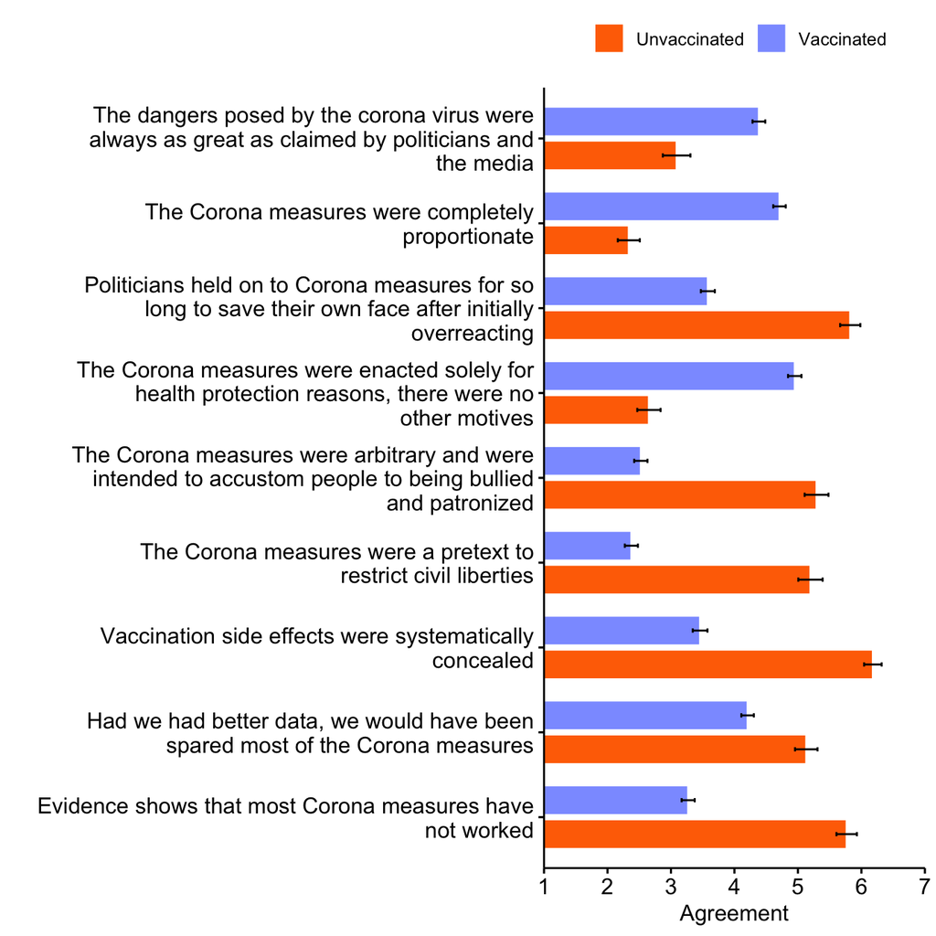

```r
recapvariables <- c("RECAP_1", "RECAP_2", "RECAP_3", "RECAP_4", "RECAP_5", "RECAP_6", "RECAP_7", "RECAP_8", "RECAP_9")

long <- melt(data[,c("VSTATUS", recapvariables)], id=c("VSTATUS"))
long$VSTATUS <- factor(long$VSTATUS, levels = c(0,1), labels = c("Unvaccinated", "Vaccinated"))

ggbarplot(
  data = long,
  x = "variable",
  y = "value",
  fill = "VSTATUS",
  add = "mean_ci",
  color = "#ffffff",
  add.params = list(color = "black"),
  position = position_dodge(0.8),
  order = rev(recapvariables)
) + scale_x_discrete(
  name = "",
  labels = c(
    "RECAP_1" = tl("The dangers posed by the corona virus were always as great as claimed by politicians and the media", 45),
    "RECAP_2" = tl("The Corona measures were completely proportionate", 45),
    "RECAP_3" = tl("Politicians held on to Corona measures for so long to save their own face after initially overreacting", 45),
    "RECAP_4" = tl("The Corona measures were enacted solely for health protection reasons, there were no other motives", 45),
    "RECAP_5" = tl("The Corona measures were arbitrary and were intended to accustom people to being bullied and patronized", 45),
    "RECAP_6" = tl("The Corona measures were a pretext to restrict civil liberties", 45),
    "RECAP_7" = tl("Vaccination side effects were systematically concealed", 45),
    "RECAP_8" = tl("Had we had better data, we would have been spared most of the Corona measures", 45),
    "RECAP_9" = tl("Evidence shows that most Corona measures have not worked", 45)
  )
) + scale_y_continuous(
  name = "Agreement",
  breaks = c(1:7),
  expand = c(0,0)
) + scale_fill_manual(
  name = "",
  values = c(
    "Unvaccinated" = "#FF7000",
    "Vaccinated" = "#8D9EFF"
  )
) + coord_flip(ylim = c(1,7))
```

## 4.2 Regression of mean appropriateness ratings on vaccination status and vaccination status identification

**Note:** After inverting items 1,2, and 4, high reliability (alpha = 0.92) allows averaging the items (see above).

```r
model <- lm(RECAP ~ IDENT * factor(VSTATUS), data=data)
tab_model(model, pred.labels = c(
  "IDENT" = "Vaccination status identification",
  "factor(VSTATUS)1" = "Vaccinated (Baseline: unvaccinated)",
  "IDENT:factor(VSTATUS)1" = "Interaction: Vaccinated x Identification"
), dv.labels = c(""), title = "Appropriateness rating", show.std=TRUE)
```

Appropriateness rating

| Predictors | Estimates | std. Beta | CI | standardized CI | p | std. p |
| --- | --- | --- | --- | --- | --- | --- |
| (Intercept) | 4.98 | -0.96 | 4.55 – 5.40 | -1.03 – -0.89 | **<0.001** | **<0.001** |
| Vaccination status identification | -0.53 | -0.42 | -0.62 – -0.44 | -0.49 – -0.35 | **<0.001** | **<0.001** |
| Vaccinated (Baseline: unvaccinated) | -2.20 | 1.32 | -2.68 – -1.71 | 1.24 – 1.40 | **<0.001** | **<0.001** |
| Interaction: Vaccinated x Identification | 0.96 | 0.77 | 0.86 – 1.06 | 0.69 – 0.85 | **<0.001** | **<0.001** |
| Observations | 1644 |  |  |  |  |  |
| R<sup>2</sup> / R<sup>2</sup> adjusted | 0.482 / 0.481 |  |  |  |  |  |

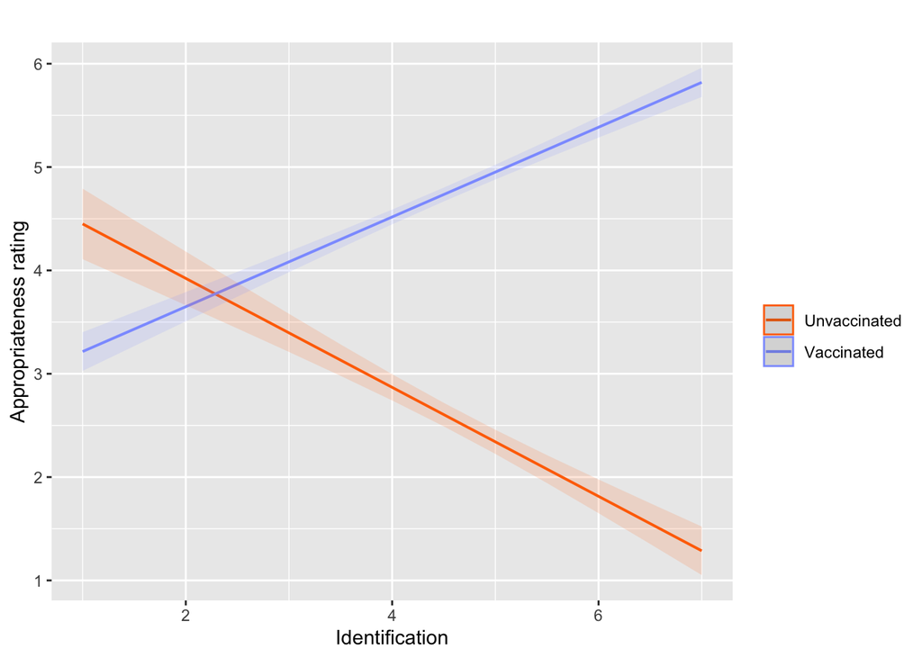

```r
model <- lm(RECAP ~ IDENT * VSTATUS, data=data)
plot_model(model, type="int") + scale_x_continuous(name = "Identification") + scale_y_continuous(name = "Appropriateness rating") + scale_fill_manual(
  name = "",
  labels = c(
    "0" = "Unvaccinated",
    "1" = "Vaccinated"
  ),
  values = c(
    "0" = "#FF7000",
    "1" = "#8D9EFF"
  )
) + scale_color_manual(
  name = "",
  labels = c(
    "0" = "Unvaccinated",
    "1" = "Vaccinated"
  ),
  values = c(
    "0" = "#FF7000",
    "1" = "#8D9EFF"
  )
) + ggtitle(label = "")
```

# 5 Recall (individual model)

```r
long <- melt(data[,c("ID", t1variables, revariables, variables)], id=c("ID"))

long$TYPE <- ifelse(str_detect(long$variable, "RE_"), "RECALL", ifelse(str_detect(long$variable, "T1_"), "TRUTH", "BIAS"))

long$VAR <- ifelse(long$TYPE != "BIAS", substring(long$variable, 4), substring(long$variable, 1))

# pomp values since some are 5-point items and some are 7-point
long$VALUE_POMP <- ifelse(long$VAR == "USE_MASK", (long$value-1)/4, (long$value-1)/6)

# reverse exaggeration perception as these are negatively correlated with the other variables
long$VALUE_POMP <- ifelse(long$VAR == "EXAGG", 1-long$VALUE_POMP, long$VALUE_POMP)

# remove life satisfaction and trust in RKI as this is merely correlated with the other variables
long <- long[long$VAR != "LIFESAT",]
long <- long[long$VAR != "TRUST_RKI",]

# long to wide
wide <- dcast(long, VAR+ID ~ TYPE, value.var = "VALUE_POMP")

### truth centering by individual
tb <- wide %>% group_by(ID) %>% plyr::summarize(
  ID = ID,
  RECALL_C = datawizard::center(RECALL, reference=TRUTH),
  BIAS_C = datawizard::center(BIAS, reference=TRUTH),
  TRUTH_C = datawizard::center(TRUTH, reference=TRUTH)
)

### regression by individual
regs <- tb %>% group_by(ID) %>% do(MODEL = lm(RECALL_C ~ BIAS_C + TRUTH_C, data = .))
regs <- regs %>% rowwise() %>% mutate(
  DIRECTIONAL_BIAS = MODEL$coefficients[1],
  BIAS_FORCE = MODEL$coefficients[2],
  TRUTH_FORCE = MODEL$coefficients[3]
) %>% select(-MODEL)

### sometimes no model can be fitted (if all ratings are the same) -> these cases are removed here
regs <- regs[!is.na(regs$DIRECTIONAL_BIAS) & !is.na(regs$BIAS_FORCE) & !is.na(regs$TRUTH_FORCE),]

### merge regression results into main data
data <- merge(data, regs, by="ID", all.x = TRUE)
```

## 5.1 Correlations of model parameters with appropriateness ratings

```r
cor.test(data$DIRECTIONAL_BIAS, data$RECAP)
```

```
##
##  Pearson's product-moment correlation
##
## data:  data$DIRECTIONAL_BIAS and data$RECAP
## t = 9.736, df = 1574, p-value < 2.2e-16
## alternative hypothesis: true correlation is not equal to 0
## 95 percent confidence interval:
##  0.1912037 0.2843625
## sample estimates:
##       cor
## 0.2383313
```

```r
cor.test(data$TRUTH_FORCE, data$RECAP)
```

```
##
##  Pearson's product-moment correlation
##
## data:  data$TRUTH_FORCE and data$RECAP
## t = -0.96357, df = 1574, p-value = 0.3354
## alternative hypothesis: true correlation is not equal to 0
## 95 percent confidence interval:
##  -0.07356962  0.02512760
## sample estimates:
##         cor
## -0.02428017
```

```r
cor.test(data$BIAS_FORCE, data$RECAP)
```

```
##
##  Pearson's product-moment correlation
##
## data:  data$BIAS_FORCE and data$RECAP
## t = -1.1347, df = 1574, p-value = 0.2567
## alternative hypothesis: true correlation is not equal to 0
## 95 percent confidence interval:
##  -0.07785792  0.02081685
## sample estimates:
##         cor
## -0.02859019
```

# 6 Validation of population recall variables

```r
data$RE_POP_SEVERITY <- ifelse(data$T1 == "summer", data$POP_SEVERITY_SUMMER, data$POP_SEVERITY_WINTER)

data$RE_POP_TRUST <- ifelse(data$T1 == "summer", data$POP_TRUST_SUMMER, data$POP_TRUST_WINTER)

data$RE_POP_TRUST_RE <- 100 - data$RE_POP_TRUST # trust is reversed coded in the population estimate

data$RE_POP_EXAGG <- ifelse(data$T1 == "summer", data$POP_EXAGG_SUMMER, data$POP_EXAGG_WINTER)

data$RE_POP_LIFESAT <- ifelse(data$T1 == "summer", data$POP_LIFESAT_SUMMER, data$POP_LIFESAT_WINTER)

###
```

## 6.1 Severity

```r
reg_1 <- lm(RE_POP_SEVERITY ~ RE_SEVERITY + SEVERITY + T1_SEVERITY  ,data = data)

tab_model(reg_1, pred.labels = c(
  "RE_SEVERITY" = "Individual Recall",
   "SEVERITY" = "Present evaluation",
   "T1_SEVERITY" = "Past valuation")
, show.std=TRUE, dv.labels = "Population estimate of past severity of infection")
```

|  | Population estimate of past severity of infection |  |  |  |  |
| --- | --- | --- | --- | --- | --- |
| Predictors | Estimates | std. Beta | CI | standardized CI | p |
| (Intercept) | 46.49 | 0.00 | 43.27 – 49.71 | -0.05 – 0.05 | **<0.001** |
| Individual Recall | 4.31 | 0.32 | 3.38 – 5.23 | 0.25 – 0.39 | **<0.001** |
| Present evaluation | -2.03 | -0.14 | -3.08 – -0.97 | -0.21 – -0.07 | **<0.001** |
| Past valuation | 0.14 | 0.01 | -0.71 – 0.99 | -0.05 – 0.07 | 0.746 |
| Observations | 1644 |  |  |  |  |
| R<sup>2</sup> / R<sup>2</sup> adjusted | 0.063 / 0.061 |  |  |  |  |

## 6.2 Trust in Goverment

```r
reg_2 <- lm(RE_POP_TRUST_RE ~ RE_TRUST_GOV + TRUST_GOV + T1_TRUST_GOV,data = data  )

tab_model(reg_2, pred.labels = c(
  "RE_TRUST_GOV" = "Individual Recall",
   "TRUST_GOV" = "Present evaluation",
   "T1_TRUST_GOV" = "Past valuation")
, show.std=TRUE, dv.labels = "Population estimate of past trust in government")
```

|  | Population estimate of past trust in government |  |  |  |  |
| --- | --- | --- | --- | --- | --- |
| Predictors | Estimates | std. Beta | CI | standardized CI | p |
| (Intercept) | 47.11 | -0.00 | 44.42 – 49.79 | -0.05 – 0.05 | **<0.001** |
| Individual Recall | 2.34 | 0.19 | 1.41 – 3.27 | 0.11 – 0.27 | **<0.001** |
| Present evaluation | -0.92 | -0.07 | -1.89 – 0.06 | -0.15 – 0.00 | 0.067 |
| Past valuation | 0.09 | 0.01 | -0.70 – 0.89 | -0.06 – 0.08 | 0.822 |
| Observations | 1600 |  |  |  |  |
| R<sup>2</sup> / R<sup>2</sup> adjusted | 0.023 / 0.021 |  |  |  |  |

## 6.3 Exaggeration perceptions

```r
reg_3 <- lm(RE_POP_EXAGG ~ RE_EXAGG + EXAGG + T1_EXAGG ,data = data )

tab_model(reg_3, pred.labels = c(
  "RE_EXAGG" = "Individual Recall",
   "EXAGG" = "Present evaluation",
   "T1_EXAGG" = "Past valuation")
, show.std=TRUE, dv.labels = "Population estimate of past exaggeration perceptions")
```

|  | Population estimate of past exaggeration perceptions |  |  |  |  |
| --- | --- | --- | --- | --- | --- |
| Predictors | Estimates | std. Beta | CI | standardized CI | p |
| (Intercept) | 36.29 | -0.00 | 33.99 – 38.59 | -0.05 – 0.05 | **<0.001** |
| Individual Recall | 1.61 | 0.15 | 0.80 – 2.41 | 0.08 – 0.23 | **<0.001** |
| Present evaluation | -0.36 | -0.03 | -1.17 – 0.45 | -0.11 – 0.04 | 0.387 |
| Past valuation | 0.82 | 0.08 | 0.13 – 1.51 | 0.01 – 0.14 | **0.020** |
| Observations | 1644 |  |  |  |  |
| R<sup>2</sup> / R<sup>2</sup> adjusted | 0.035 / 0.033 |  |  |  |  |

## 6.4 Life satisfaction

```r
reg_4 <- lm(RE_POP_LIFESAT ~ RE_LIFESAT + LIFESAT + T1_LIFESAT ,data = data )

tab_model(reg_4, pred.labels = c(
  "RE_LIFESAT" = "Individual Recall",
   "LIFESAT" = "Present evaluation",
   "T1_LIFESAT" = "Past valuation")
, show.std=TRUE, dv.labels = "Population estimate of past life satisfaction")
```

|  | Population estimate of past life satisfaction |  |  |  |  |
| --- | --- | --- | --- | --- | --- |
| Predictors | Estimates | std. Beta | CI | standardized CI | p |
| (Intercept) | 36.78 | 0.00 | 32.47 – 41.09 | -0.05 – 0.05 | **<0.001** |
| Individual Recall | 3.95 | 0.27 | 3.00 – 4.90 | 0.21 – 0.34 | **<0.001** |
| Present evaluation | -0.91 | -0.06 | -1.99 – 0.16 | -0.13 – 0.01 | 0.097 |
| Past valuation | -0.12 | -0.01 | -0.97 – 0.73 | -0.07 – 0.05 | 0.777 |
| Observations | 1539 |  |  |  |  |
| R<sup>2</sup> / R<sup>2</sup> adjusted | 0.055 / 0.053 |  |  |  |  |